# =========================================

# TECH CHALLENGE - FASE 1

# Grupo: 12

# =========================================

Tema:

## **Impacto da Logística na Satisfação do Cliente e Crescimento do Marketplace**

## 0 - Configuração do Ambiente Analítico

Antes do início das análises, foi necessária a preparação do ambiente analítico responsável pelo processamento, integração e exploração dos dados do marketplace Olist.

Essa etapa tem como objetivo garantir a reprodutibilidade do estudo, a padronização dos procedimentos analíticos e a confiabilidade dos resultados apresentados ao longo do relatório. Para isso, foram definidas as bibliotecas, funções auxiliares, padrões visuais e estruturas de dados que serão utilizadas em todas as etapas da análise.

Além da organização do ambiente computacional, esta seção estabelece os critérios de governança adotados no projeto, incluindo nomenclaturas padronizadas, tratamento de dados, validações de qualidade e diretrizes de visualização. Essas definições contribuem para a consistência metodológica do trabalho e facilitam a interpretação dos resultados por diferentes públicos.

A construção de um ambiente estruturado também reduz riscos de inconsistências durante o desenvolvimento das análises, permitindo que os indicadores sejam calculados de forma padronizada e que os resultados possam ser reproduzidos futuramente.

Dessa forma, esta etapa estabelece a base técnica necessária para o desenvolvimento das análises exploratórias, diagnósticas e investigativas que serão apresentadas nas seções seguintes.

### 0.1 - Importação das Bibliotecas

**Problema de Negócio**

As análises propostas neste estudo dependem de ferramentas capazes de realizar manipulação de dados, cálculos estatísticos, visualizações gráficas e gerenciamento de arquivos. Sem a configuração adequada dessas bibliotecas, não é possível garantir eficiência, padronização e reprodutibilidade do processo analítico.

**Objetivo**

Importar as bibliotecas necessárias para suportar todas as etapas do projeto, incluindo preparação dos dados, análises exploratórias, construção de indicadores e geração de visualizações executivas.

**Hipótese**

A utilização de bibliotecas amplamente adotadas pela comunidade de Data Analytics contribuirá para aumentar a confiabilidade, a produtividade e a reprodutibilidade das análises realizadas ao longo do projeto.

**Decisão Apoiada**

Definir o conjunto de ferramentas que servirá como base para o desenvolvimento de todas as análises e visualizações apresentadas neste relatório.

### 0.2 - Configuração do pandas

Objetivo: Configurar a biblioteca Pandas para melhorar a visualização e interpretação dos dados durante a análise exploratória.

Decisão que apoia: Facilitar a identificação de padrões, inconsistências e características dos dados sem perda de informação visual.

### 0.3 - Configurações de Visualização

**Problema de Negócio**

A ausência de padrões visuais pode gerar inconsistências na apresentação dos gráficos, dificultando a comparação entre análises e comprometendo a clareza da comunicação dos resultados ao longo do projeto.

**Objetivo**

Definir configurações visuais padronizadas para os gráficos, garantindo uniformidade na apresentação das informações e facilitando a interpretação dos insights gerados.

**Hipótese**

A adoção de um padrão visual consistente contribuirá para melhorar a legibilidade dos gráficos, fortalecer o storytelling analítico e tornar a comunicação dos resultados mais eficiente.

**Decisão Apoiada**

Estabelecer uma identidade visual única para todas as análises do projeto, assegurando consistência gráfica e melhor experiência de leitura para os usuários e avaliadores do relatório.

### 0.4 - Criação de Funções de Apoio à Análise

**Problema de Negócio**

Durante o desenvolvimento de projetos analíticos, diversas tarefas são executadas repetidamente, como inspeção de bases, validação de qualidade dos dados, cálculo de indicadores e formatação de resultados. A repetição dessas atividades aumenta o esforço operacional, eleva o risco de inconsistências e dificulta a manutenção do código.

**Objetivo**

Desenvolver funções reutilizáveis para automatizar tarefas recorrentes de exploração e análise dos dados, aumentando a produtividade, a padronização e a reprodutibilidade do projeto.

**Hipótese**

A utilização de funções padronizadas reduzirá a duplicidade de código, minimizará erros operacionais e permitirá maior eficiência na exploração e interpretação dos dados ao longo do estudo.

**Decisão Apoiada**

Definir uma estrutura de apoio analítico capaz de acelerar a compreensão inicial dos dados, garantir consistência metodológica e direcionar as próximas etapas da análise exploratória.

### 0.5 - Conexão com Google Drive

**Problema de Negócio**

Projetos de análise de dados dependem do acesso consistente e confiável às fontes de informação utilizadas ao longo do estudo. A ausência de uma conexão centralizada com os arquivos pode dificultar a atualização dos dados, aumentar o risco de utilização de versões incorretas e comprometer a reprodutibilidade das análises.

**Objetivo**

Estabelecer a conexão entre o ambiente de análise e o local de armazenamento dos dados, garantindo acesso seguro e centralizado aos arquivos utilizados no projeto.

**Hipótese**

A utilização de um repositório centralizado para armazenamento dos dados facilitará o gerenciamento das bases, reduzirá riscos operacionais e contribuirá para a consistência das análises realizadas.

**Decisão Apoiada**

Assegurar que todas as análises sejam executadas sobre fontes de dados corretas, atualizadas e acessíveis, promovendo maior confiabilidade e reprodutibilidade dos resultados apresentados neste estudo.

### 0.6 - Organização e Validação dos Arquivos de Dados

**Problema de Negócio**

A utilização de arquivos incorretos, incompletos ou indisponíveis pode comprometer toda a análise, gerando resultados inconsistentes e reduzindo a confiabilidade das conclusões obtidas. Antes da importação dos dados, é necessário garantir que todas as bases estejam corretamente localizadas e identificadas.

**Objetivo**

Organizar e validar a estrutura dos arquivos utilizados no projeto, garantindo que as bases estejam localizadas, acessíveis e corretamente identificadas antes da importação.

**Hipótese**

A validação prévia dos arquivos reduzirá riscos de erros operacionais, aumentará a confiabilidade do processo de carga dos dados e facilitará a identificação de eventuais problemas antes do início das análises.

**Decisão Apoiada**

Assegurar que a análise será realizada utilizando os arquivos corretos e completos, evitando falhas de leitura, ausência de bases ou utilização de dados inadequados para responder às perguntas de negócio do estudo.

#### 0.6.1 - Definição dos Caminhos de Acesso

Foi definido o diretório principal do projeto no Google Drive, que será utilizado como referência para acesso aos arquivos de dados, documentos de apoio e demais artefatos necessários para a execução das análises.

```
/content/drive/MyDrive/Tech Challenge 1
```

#### 0.6.2 - Identificação dos Arquivos de Dados

Objetivo: Listar os arquivos disponíveis dentro da pasta definida.

Decisão que apoia: Conferir se os arquivos esperados estão presentes antes da importação.

Pergunta: **Quais arquivos existem na pasta do projeto?**

```
POSTECH - [DTAT] - Tech Challenge - Fase 1.pdf
olist_sellers_dataset.csv
olist_products_dataset.csv
olist_orders_dataset.csv
olist_order_reviews_dataset.csv
olist_order_payments_dataset.csv
olist_order_items_dataset.csv
olist_geolocation_dataset.csv
olist_customers_dataset.csv
olist_orders_dataset (1).gsheet
olist_orders_dataset.gsheet
Arquivos Python_Collab
POSTECH - [DTAT] - Tech Challenge - Fase 1.gdoc
olist_order_reviews_dataset.gsheet
5 Porques - Satisfação do Cliente.docx
Roteiro relatório.gdoc
Relatorio Executivo - Tech Challenge - Grupo 12.docx
```

#### 0.6.3 - Validação dos Arquivos Disponíveis

Pergunta: **Todos os arquivos necessários estão presentes?**

```
Validação dos arquivos necessários para o projeto:

✅ olist_customers_dataset.csv
✅ olist_orders_dataset.csv
✅ olist_order_items_dataset.csv
✅ olist_products_dataset.csv
✅ olist_order_reviews_dataset.csv
✅ olist_order_payments_dataset.csv
✅ olist_sellers_dataset.csv
✅ olist_geolocation_dataset.csv
```

#### 0.6.4 - Validação da Importação

```
customers_df: (99441, 5)
orders_df: (99441, 8)
order_items_df: (112650, 7)
products_df: (32951, 9)
reviews_df: (99224, 7)
payments_df: (103886, 5)
sellers_df: (3095, 4)
geolocation_df: (1000163, 5)
```

## Conclusão da Seção 0 – Configuração do Ambiente Analítico

A configuração do ambiente analítico estabeleceu a base técnica necessária para o desenvolvimento deste estudo. Ao longo desta seção, foram definidas as bibliotecas, configurações visuais, funções de apoio e mecanismos de acesso aos dados que garantirão padronização, organização e reprodutibilidade das análises realizadas nas próximas etapas.

Também foram implementadas práticas de validação e governança dos dados, assegurando que as bases utilizadas estejam acessíveis, corretamente identificadas e preparadas para o processo de exploração analítica. Essas medidas contribuem para reduzir riscos operacionais, aumentar a confiabilidade dos resultados e facilitar a manutenção do projeto ao longo de seu desenvolvimento.

A construção de um ambiente estruturado permite que as análises subsequentes sejam executadas de forma consistente, garantindo que os indicadores, visualizações e conclusões apresentados neste relatório estejam fundamentados em procedimentos padronizados e reproduzíveis.

Com a infraestrutura analítica devidamente preparada, o próximo passo consiste em compreender a estrutura dos dados disponíveis, identificar suas características e avaliar seu potencial para responder às perguntas de negócio propostas neste estudo.

## 1 - Introdução e Contexto de Negócio

O comércio eletrônico tem desempenhado um papel cada vez mais relevante na economia digital, impulsionando a transformação da forma como consumidores pesquisam, compram e avaliam produtos e serviços. Nesse ambiente altamente competitivo, compreender os fatores que influenciam o desempenho operacional e a satisfação dos clientes tornou-se essencial para a sustentabilidade e o crescimento dos marketplaces.

A Olist atua como uma plataforma que conecta milhares de lojistas a diferentes marketplaces, permitindo ampliar o alcance comercial de pequenos e médios vendedores em todo o território nacional. Como resultado dessa operação, são gerados grandes volumes de dados relacionados a pedidos, produtos, pagamentos, logística, vendedores e avaliações dos consumidores, criando oportunidades para análises que apoiem a tomada de decisão baseada em evidências.

Para investidores e gestores, indicadores financeiros como receita, volume de pedidos e ticket médio são fundamentais para avaliar o crescimento do negócio. Entretanto, esses indicadores, isoladamente, não explicam os fatores que contribuem para uma experiência positiva de compra nem os elementos que influenciam a percepção dos clientes sobre a plataforma.

Dessa forma, torna-se necessário investigar não apenas o desempenho comercial do marketplace, mas também aspectos relacionados à eficiência logística e à satisfação dos consumidores. A compreensão desses fatores permite identificar oportunidades de melhoria operacional, mitigação de riscos e direcionamento mais eficiente dos investimentos.

Este estudo utiliza o Brazilian E-Commerce Public Dataset by Olist para analisar o comportamento do marketplace entre os anos de 2016 e 2018. A partir da integração e exploração dos dados, busca-se identificar padrões, tendências e relações capazes de explicar os principais direcionadores de desempenho da plataforma.

A análise está orientada pela seguinte pergunta de negócio:

**Quais fatores da experiência de compra exercem maior influência sobre a satisfação dos clientes da Olist?**

Para responder essa questão, serão investigados aspectos relacionados ao crescimento comercial, eficiência logística e comportamento das avaliações dos consumidores, com o objetivo de gerar recomendações estratégicas fundamentadas em dados e alinhadas à perspectiva de investidores e tomadores de decisão.

### 1.1 - Contexto do Negócio

A Olist é uma **empresa brasileira** de tecnologia fundada em 2015 que atua como um **ecossistema digital** voltado à digitalização e ao crescimento de pequenos e médios lojistas. Por meio de uma plataforma integrada, a empresa conecta vendedores a diversos canais de venda online, simplificando processos operacionais e ampliando o acesso dessas empresas ao comércio eletrônico (OLIST, 2025).

Seu modelo de negócio está fundamentado na criação de valor para diferentes participantes do ecossistema. Enquanto os lojistas ampliam sua visibilidade e alcance comercial, os consumidores passam a ter acesso a uma maior variedade de produtos e ofertas. Nesse contexto, o crescimento da plataforma está diretamente relacionado à capacidade de atrair vendedores, ampliar o volume de transações e proporcionar uma experiência de compra satisfatória ao cliente final (OLIST, 2025).

Em ambientes digitais, a experiência do cliente tornou-se um fator estratégico para a competitividade das plataformas de comércio eletrônico. Diferentemente do varejo físico, em que o consumidor tem contato imediato com o produto, a jornada digital depende da eficiência de diversos processos operacionais, incluindo aprovação do pedido, processamento da compra, expedição e entrega. Dessa forma, a percepção de qualidade do serviço está diretamente associada à capacidade da operação de atender às expectativas dos consumidores (KOTLER; KELLER, 2012).

Nesse cenário, a logística assume papel relevante ao conectar a operação dos vendedores à experiência percebida pelos clientes. O cumprimento dos prazos de entrega, a previsibilidade da operação e a redução de falhas ao longo da jornada de compra contribuem para fortalecer a confiança dos consumidores e a percepção de qualidade do serviço. Por outro lado, atrasos e inconsistências operacionais podem comprometer a experiência de compra e impactar negativamente a reputação dos participantes do ecossistema (CHOPRA; MEINDL, 2016).

Sob a perspectiva de investidores e acionistas, indicadores relacionados à satisfação dos clientes, eficiência operacional, desempenho logístico e evolução das vendas representam importantes sinais da capacidade de crescimento e sustentabilidade do negócio. Nesse contexto, compreender a relação entre esses fatores torna-se relevante para apoiar decisões estratégicas, identificar oportunidades de melhoria operacional e avaliar elementos que podem contribuir para a geração de valor no longo prazo.

### 1.2 - Evolução da Empresa

[figure not shown]

### Insight Executivo

A linha do tempo demonstra a evolução da Olist desde sua fundação até sua consolidação como solução para pequenos e médios lojistas venderem em marketplaces. Esse contexto ajuda investidores a compreenderem que a empresa atua em um mercado com histórico de crescimento e digitalização do varejo.

### Recomendação

Utilizar essa linha do tempo como abertura narrativa do projeto, conectando a trajetória da Olist ao objetivo da análise: avaliar desempenho comercial, eficiência logística e satisfação do cliente com base em dados reais do e-commerce brasileiro.

### 1.3 - Problema de Negócio

Em plataformas digitais que conectam vendedores e consumidores, a **experiência de compra** representa um fator fundamental para a competitividade e sustentabilidade do negócio. Entretanto, diferentes elementos da **jornada do cliente**, como prazo de entrega, atrasos logísticos, características dos produtos, localização geográfica e desempenho comercial, podem influenciar a percepção de valor e a satisfação dos consumidores.

Diante desse contexto, torna-se relevante compreender **quais fatores exercem maior influência sobre a experiência do cliente e como esses aspectos se relacionam com o desempenho operacional e comercial do ecossistema da Olist.** A identificação desses fatores pode apoiar decisões estratégicas voltadas à melhoria da operação, à priorização de investimentos e à geração de valor para o negócio.

### 1.4 - Pergunta do Negócio (pergunta norteadora)

Quais fatores da experiência de compra influenciam a satisfação dos clientes e o desempenho do e-commerce da Olist, e de que forma esses fatores podem apoiar decisões estratégicas voltadas ao crescimento sustentável do negócio?

### 1.5 - Objetivo do Projeto

Este projeto tem como **objetivo analisar o desempenho do e-commerce da Olist** a partir de dados transacionais, **com foco em satisfação dos clientes, eficiência logística, crescimento comercial e geração de receita.**

A análise busca investigar como fatores relacionados à experiência de compra, como prazo de entrega, atrasos logísticos, características dos produtos, localização dos clientes e desempenho das vendas, se relacionam com a satisfação dos consumidores e com o desempenho do negócio.

Com base nos resultados obtidos, **serão elaborados insights executivos** **e recomendações estratégicas** que possam apoiar a tomada de decisão, a identificação de oportunidades de melhoria operacional e o acompanhamento de indicadores relevantes para o crescimento sustentável da empresa.

### 1.6 Hipóteses da Análise

Com base no contexto do negócio e nos fatores que influenciam a experiência de compra em plataformas digitais, foram definidas as seguintes hipóteses para investigação:

**H1. Clientes que recebem seus pedidos em menor prazo tendem a apresentar maiores níveis de satisfação.**

**H2. Atrasos na entrega estão associados a avaliações mais baixas dos consumidores**.

**H3. Existem diferenças de satisfação entre regiões geográficas devido a fatores operacionais e logísticos.**

**H4. Algumas categorias de produtos apresentam níveis de satisfação distintos em função de características relacionadas à experiência de compra.**

**H5. Indicadores operacionais e logísticos apresentam relação com o desempenho percebido pelos clientes e podem representar oportunidades de melhoria para o negócio.**

### Principais Resultados Seção 1

- O contexto de negócio do marketplace Olist foi apresentado, conectando o crescimento do e-commerce à necessidade de análise baseada em dados.
- Foi definida a pergunta central do estudo: quais fatores da experiência de compra exercem maior influência sobre a satisfação dos clientes.
- A seção posiciona a análise sob a perspectiva de investidores e tomadores de decisão.
- O estudo foi direcionado para investigar desempenho comercial, eficiência logística e satisfação dos consumidores.

### Insight Executivo

A introdução estabelece a base estratégica do projeto ao conectar dados transacionais da Olist a uma pergunta de negócio relevante para investidores. Ao direcionar a análise para satisfação dos clientes, desempenho comercial e eficiência logística, o estudo deixa de ser apenas uma exploração de dados e passa a construir uma narrativa orientada à tomada de decisão.

### Recomendação

Utilizar a pergunta central definida nesta seção como eixo condutor das próximas análises, garantindo que cada gráfico, indicador e conclusão contribua diretamente para explicar os fatores que influenciam a satisfação dos clientes e apoiar recomendações estratégicas para o marketplace.

## 2 - Entendimento e Preparação dos Dados

Após a definição do problema de negócio e dos objetivos da análise, torna-se necessário compreender a estrutura dos dados disponibilizados pela Olist.

Nesta etapa são realizadas a leitura das bases, padronização dos conjuntos de dados e análise dos relacionamentos entre as tabelas que compõem o ecossistema do marketplace.

O entendimento da estrutura dos dados é fundamental para garantir a correta interpretação das informações, evitar inconsistências analíticas e assegurar que as métricas utilizadas nas etapas posteriores representem adequadamente os fenômenos observados.

### 2.1 - Visão Geral do Dataset

**Problema de Negócio**

Antes de analisar os fatores que influenciam a satisfação dos clientes, é necessário compreender quais dados estão disponíveis e se eles são capazes de representar adequadamente a operação do marketplace da Olist.

**Objetivo**

Apresentar uma visão geral do conjunto de dados disponibilizado pela Olist, identificando as principais tabelas, entidades e informações disponíveis para análise.

**Hipótese**

O dataset contém informações suficientes para representar a jornada dos clientes, os processos logísticos e os resultados operacionais do marketplace.

**Decisão Apoiada**

Determinar se os dados disponíveis são adequados para responder às hipóteses e perguntas de negócio definidas no projeto.

| tabela | descrição | linhas | colunas | granularidade |
| --- | --- | --- | --- | --- |
| customers | Informações dos clientes | 99.441 | 5 | 1 linha = 1 cliente |
| orders | Informações dos pedidos | 99.441 | 8 | 1 linha = 1 pedido |
| order_items | Itens vendidos por pedido | 112.650 | 7 | 1 linha = 1 item vendido |
| products | Catálogo de produtos | 32.951 | 9 | 1 linha = 1 produto |
| reviews | Avaliações dos clientes | 99.224 | 7 | 1 linha = 1 avaliação |
| payments | Informações de pagamento | 103.886 | 5 | 1 linha = 1 pagamento |
| sellers | Informações dos vendedores | 3.095 | 4 | 1 linha = 1 vendedor |
| geolocation | Coordenadas geográficas por CEP | 1.000.163 | 5 | 1 linha = 1 localização por CEP |

### Principais Resultados

Foram identificadas bases contendo informações de clientes, pedidos, produtos, vendedores, pagamentos, avaliações e localização geográfica, permitindo analisar diferentes dimensões da operação da Olist.

### Insight Executivo

O conjunto de dados apresenta cobertura abrangente da jornada de compra dos clientes e fornece informações suficientes para investigar fatores relacionados à satisfação e ao desempenho operacional.

### Recomendação

Prosseguir com a leitura e exploração detalhada das tabelas para compreender sua estrutura e potencial analítico.

### 2.2 - Leitura das Tabelas

**Problema de Negócio**

É necessário compreender quais informações estão disponíveis no dataset antes de iniciar qualquer análise.

**Objetivo**

Realizar a leitura das tabelas e identificar as principais entidades que compõem o ecossistema da Olist.

**Hipótese**

As tabelas representam diferentes etapas da jornada de compra dos clientes e podem ser integradas para responder às perguntas de negócio.

**Decisão Apoiada**

Determinar quais bases serão utilizadas na construção da base analítica consolidada.

Estrutura e Volume das Bases do Dataset Olist

| Tabela | Linhas | Colunas | Descrição | Granularidade |
| --- | --- | --- | --- | --- |
| customers | 99.441 | 5 | Informações dos clientes | 1 linha = 1 cliente |
| orders | 99.441 | 8 | Informações dos pedidos | 1 linha = 1 pedido |
| order_items | 112.650 | 7 | Itens vendidos por pedido | 1 linha = 1 item vendido |
| products | 32.951 | 9 | Catálogo de produtos | 1 linha = 1 produto |
| reviews | 99.224 | 7 | Avaliações dos clientes | 1 linha = 1 avaliação |
| payments | 103.886 | 5 | Informações de pagamento | 1 linha = 1 pagamento |
| sellers | 3.095 | 4 | Informações dos vendedores | 1 linha = 1 vendedor |
| geolocation | 1.000.163 | 5 | Coordenadas geográficas por CEP | 1 linha = 1 localização por CEP |

### Principais Resultados

As tabelas foram carregadas com sucesso e representam informações de clientes, pedidos, produtos, vendedores, pagamentos, avaliações e localização geográfica.

### Insight Executivo

O dataset possui cobertura suficiente para representar a jornada completa dos clientes dentro do marketplace.

### Recomendação

Prosseguir com a padronização e análise estrutural das tabelas antes da integração dos dados.

### 2.3 - Padronização dos Nomes das Tabelas

**Problema de Negócio**

Nomenclaturas inconsistentes dificultam a interpretação e manutenção do projeto.

**Objetivo**

Padronizar nomes de tabelas e variáveis para aumentar a legibilidade e facilitar futuras análises.

**Hipótese**

A adoção de nomenclaturas padronizadas reduzirá erros de interpretação e aumentará a clareza do notebook.

**Decisão Apoiada**

Estabelecer um padrão único de nomenclatura para todo o projeto.

Padronização dos DataFrames Utilizados no Projeto

| DataFrame | Descrição em português |
| --- | --- |
| customers | Informações dos clientes |
| orders | Informações dos pedidos |
| order_items | Itens vendidos por pedido |
| products | Catálogo de produtos |
| reviews | Avaliações dos clientes |
| payments | Informações de pagamento |
| sellers | Informações dos vendedores |
| geolocation | Coordenadas geográficas por CEP |

### Principais Resultados

Os nomes das tabelas foram padronizados para um formato consistente e de fácil compreensão.

### Insight Executivo

A padronização melhora a governança dos dados e reduz riscos de inconsistências durante a análise.

### Recomendação

Manter o padrão definido em todas as etapas subsequentes do projeto.

### 2.4 - Relacionamentos e Cardinalidade

**Problema de Negócio**

A integração incorreta das tabelas pode gerar duplicidades, distorções métricas e interpretações equivocadas dos resultados.

**Objetivo**

Compreender os relacionamentos existentes entre as tabelas da Olist e identificar a granularidade adequada de cada conjunto de dados.

**Hipótese**

As tabelas possuem relacionamentos consistentes e podem ser integradas por meio de chaves de ligação capazes de preservar a integridade dos dados.

**Decisão Apoiada**

Definir a estratégia correta de integração das tabelas e garantir a construção de uma base analítica consistente.

#### 2.4.1 Análise da Granularidade das Tabelas

| tabela | granularidade | chave_principal | risco_analitico |
| --- | --- | --- | --- |
| customers | 1 linha = 1 cliente | customer_id | Baixo risco de duplicidade |
| orders | 1 linha = 1 pedido | order_id | Base central da análise |
| order_items | 1 linha = 1 item vendido dentro de um pedido | order_id + order_item_id | Pode duplicar pedidos em merges |
| products | 1 linha = 1 produto | product_id | Baixo risco se integrada por product_id |
| reviews | 1 linha = 1 avaliação de pedido | review_id | Pode haver mais de uma avaliação por pedido |
| payments | 1 linha = 1 pagamento associado a um pedido | order_id + payment_sequential | Pode haver mais de um pagamento por pedido |
| sellers | 1 linha = 1 vendedor | seller_id | Baixo risco se integrada por seller_id |
| geolocation | 1 linha = 1 registro geográfico por CEP | geolocation_zip_code_prefix | Pode conter múltiplos registros por CEP |

#### Principais Resultados Tabela 2.4.1

- Cada tabela representa uma entidade específica do ecossistema Olist.
- Foram identificados diferentes níveis de granularidade entre pedidos, itens, produtos, clientes, vendedores e avaliações.
- As tabelas `order_items` e `payments` apresentam granularidade mais detalhada que a tabela de pedidos.
- A compreensão dessas diferenças é fundamental para evitar duplicidade de registros durante os merges.

#### Insight Executivo

A identificação da granularidade das tabelas constitui uma etapa crítica para a qualidade das análises. O entendimento correto do nível de detalhe de cada base reduz riscos de inconsistências estatísticas e assegura que os indicadores calculados reflitam adequadamente a realidade operacional do marketplace.

#### Recomendação

Utilizar a tabela de pedidos como eixo central das integrações e considerar explicitamente a granularidade de cada base antes da realização de merges e cálculos agregados.

##### 2.4.1.1 - Investigação Complementar da Granularidade

**Problema de Negócio**

Algumas tabelas podem apresentar relações não evidentes apenas pela documentação estrutural, exigindo validações complementares para confirmar o comportamento real dos dados.

**Objetivo**

Validar empiricamente a granularidade das principais tabelas do dataset por meio da análise de registros únicos e relacionamentos observados nos dados.

**Hipótese**

Existem tabelas cuja granularidade efetiva difere da percepção inicial, tornando necessária uma investigação complementar para evitar interpretações equivocadas.

**Decisão Apoiada**

Confirmar as regras de negócio implícitas no dataset e reduzir riscos de erro na construção da base analítica.

| Tabela | Chave analisada inicialmente | Resultado observado | Chave mais adequada | Interpretação |
| --- | --- | --- | --- | --- |
| Avaliações | order_id | O order_id pode se repetir, pois um pedido pode possuir mais de uma avaliação | review_id | A granularidade da tabela está no nível da avaliação |
| Itens dos Pedidos | order_id | O order_id se repete, pois um pedido pode conter mais de um item | order_id + order_item_id | A granularidade da tabela está no nível do item vendido dentro do pedido |

```
True
```

```
Total de pedidos únicos: 98,666
```

##### Principais Resultados Tabela 2.4.1.1

- A tabela de pedidos apresenta um registro por pedido.
- A tabela de itens apresenta múltiplos registros para um mesmo pedido.
- A tabela de avaliações possui predominância de uma avaliação por pedido, embora existam exceções.
- As validações confirmaram a necessidade de cuidados específicos durante as integrações.

##### Insight Executivo

A investigação complementar permitiu validar empiricamente a estrutura do dataset, aumentando a confiabilidade das etapas subsequentes e reduzindo riscos de inconsistências metodológicas.

##### Recomendação

Documentar as exceções identificadas e considerar essas particularidades durante a construção da base analítica.

#### 2.4.2 - Relacionamento entre Tabelas

**Problema de Negócio**

A integração incorreta das tabelas pode gerar perda de registros, duplicidades e distorções nos indicadores utilizados para apoiar decisões de negócio.

**Objetivo**

Mapear os relacionamentos existentes entre as tabelas do dataset e identificar as chaves responsáveis pela integração das informações.

**Hipótese**

O dataset apresenta relacionamentos consistentes entre as entidades de negócio, permitindo a construção de uma base analítica integrada e confiável.

**Decisão Apoiada**

Definir a estratégia de integração dos dados que será utilizada na construção da base analítica consolidada.

| tabela_origem | tabela_destino | chave_ligacao | tipo_relacionamento |
| --- | --- | --- | --- |
| customers | orders | customer_id | 1:N |
| orders | order_items | order_id | 1:N |
| order_items | products | product_id | N:1 |
| order_items | sellers | seller_id | N:1 |
| orders | reviews | order_id | 1:1* |
| orders | payments | order_id | 1:N |

```
Linhas: 99224
Reviews únicos: 98410
geolocation_zip_code_prefix: 19015 valores únicos de 1000163 linhas
geolocation_lat: 717360 valores únicos de 1000163 linhas
geolocation_lng: 717613 valores únicos de 1000163 linhas
geolocation_city: 8011 valores únicos de 1000163 linhas
geolocation_state: 27 valores únicos de 1000163 linhas
```

```
720154
```

```
True
```

| Relacionamento | Chave de ligação | Importância analítica |
| --- | --- | --- |
| Pedidos x Clientes | customer_id | Permite associar pedidos aos estados e cidades dos clientes |
| Pedidos x Itens | order_id | Permite detalhar os produtos vendidos em cada pedido |
| Itens x Produtos | product_id | Permite associar itens vendidos às categorias dos produtos |
| Itens x Vendedores | seller_id | Permite analisar desempenho dos vendedores |
| Pedidos x Avaliações | order_id | Permite relacionar pedidos às notas de satisfação dos clientes |

Relacionamentos entre as Tabelas do Dataset Olist

| Tabela Origem | Chave Origem | Tabela Relacionada | Chave Relacionada | Cardinalidade | Interpretação |
| --- | --- | --- | --- | --- | --- |
| customers | customer_id | orders | customer_id | 1:N | Um cliente pode realizar um ou mais pedidos |
| orders | order_id | order_items | order_id | 1:N | Um pedido pode conter um ou mais itens |
| orders | order_id | reviews | order_id | 1:N | Um pedido pode possuir uma ou mais avaliações |
| orders | order_id | payments | order_id | 1:N | Um pedido pode possuir um ou mais pagamentos |
| orders | order_id | customers | customer_id | N:1 | Muitos pedidos pertencem a um cliente |
| order_items | product_id | products | product_id | N:1 | Muitos itens podem estar associados ao mesmo produto |
| order_items | seller_id | sellers | seller_id | N:1 | Muitos itens podem estar associados ao mesmo vendedor |

#### Principais Resultados Tabela 2.4.2

- Foram identificadas as chaves primárias e estrangeiras utilizadas nas integrações.
- A tabela de pedidos atua como elemento central do modelo analítico.
- Os relacionamentos entre clientes, pedidos, itens, produtos, vendedores, pagamentos e avaliações foram mapeados.
- A estrutura observada permite a construção de uma visão integrada da jornada de compra.

### Insight Executivo

O mapeamento dos relacionamentos evidencia que a tabela de pedidos representa o principal ponto de conexão entre as diferentes entidades do marketplace. Essa característica favorece a construção de análises integradas sobre comportamento dos clientes, desempenho comercial e eficiência logística.

### Recomendação

Utilizar o modelo de relacionamento identificado como referência para todos os merges realizados nas próximas etapas do projeto, documentando explicitamente as regras de integração adotadas.

##### 2.4.2.1 - Representação visual dos relacionamentos

```
                         clientes
                          │
                          ↓

                       pedidos
                 ┌────────┼────────┐
                 ↓        ↓        ↓

            pagamentos avaliacoes itens_pedido
                                  /      \
                                 ↓        ↓

                            produtos  vendedores
```

#### 2.4.3 - Síntese das Regras de Integração

**Problema de Negócio**

A integração entre tabelas com diferentes níveis de granularidade pode gerar duplicidades, perda de registros ou distorções nos indicadores analisados. Sem regras claras de integração, métricas como receita, volume de pedidos, frete médio e avaliação média podem ser calculadas incorretamente.

**Objetivo**

Consolidar as principais regras de integração entre as tabelas do dataset Olist, documentando as chaves de ligação, os riscos analíticos e os cuidados necessários para a construção da base analítica.

**Hipótese**

A definição prévia das regras de integração reduzirá riscos de inconsistências e aumentará a confiabilidade das análises realizadas nas próximas seções.

**Decisão Apoiada**

Definir quais cuidados devem ser adotados nos merges entre tabelas para garantir que os indicadores sejam calculados no nível correto de análise.

| tabela | granularidade | chave_principal | risco_principal |
| --- | --- | --- | --- |
| customers | 1 cliente | customer_id | Baixo |
| orders | 1 pedido | order_id | Base central |
| order_items | 1 item vendido | order_id + order_item_id | Duplicidade de pedidos |
| products | 1 produto | product_id | Baixo |
| reviews | 1 avaliação | review_id | Duplicidade de avaliações |
| payments | 1 pagamento | order_id + payment_sequential | Duplicidade de pagamentos |
| sellers | 1 vendedor | seller_id | Baixo |
| geolocation | 1 CEP | geolocation_zip_code_prefix | Duplicidade por CEP |

| relacionamento | resultado |
| --- | --- |
| orders → customers | ✔ Integridade Confirmada |
| order_items → orders | ✔ Integridade Confirmada |
| order_items → products | ✔ Integridade Confirmada |
| order_items → sellers | ✔ Integridade Confirmada |
| reviews → orders | ✔ Integridade Confirmada |
| payments → orders | ✔ Integridade Confirmada |

#### Principais Resultados Tabela 2.4.3

- Foram consolidadas as principais regras de integração entre as tabelas do dataset Olist.
- A tabela `orders` foi identificada como uma das principais bases de referência para construção da visão integrada dos pedidos.
- As tabelas `order_items`, `payments`, `reviews` e `geolocation` exigem maior cuidado por apresentarem risco de duplicidade em integrações diretas.
- A definição das regras de integração contribui para reduzir inconsistências no cálculo de indicadores como receita, frete, volume de pedidos e avaliação média.

### Insight Executivo

A definição das regras de integração fortalece a governança analítica do projeto, pois estabelece critérios claros para unir bases com diferentes níveis de granularidade. Esse cuidado é essencial para garantir que os resultados apresentados nas próximas seções reflitam corretamente o comportamento operacional e comercial do marketplace.

### Recomendação

Utilizar esta síntese como referência técnica para todos os merges realizados no projeto, priorizando a consolidação prévia de tabelas com relação 1:N antes da construção de indicadores executivos.

## Principais Resultados Seção 2

- Foram identificadas e documentadas as oito tabelas que compõem o dataset Olist, abrangendo informações sobre clientes, pedidos, itens vendidos, produtos, avaliações, pagamentos, vendedores e geolocalização.
- A análise estrutural confirmou que as bases possuem diferentes níveis de granularidade, exigindo cuidados específicos durante os processos de integração e agregação dos dados.
- A tabela `orders` foi identificada como um dos principais elementos de conexão entre as entidades do marketplace, permitindo integrar informações comerciais, logísticas e de satisfação dos clientes.
- Foram mapeadas as principais chaves de relacionamento entre as tabelas, possibilitando a construção de uma base analítica integrada e consistente.
- A investigação das regras de integração evidenciou riscos potenciais de duplicidade em tabelas como `order_items`, `payments`, `reviews` e `geolocation`, reforçando a necessidade de tratamentos específicos antes dos merges.
- A estrutura dos dados mostrou-se adequada para investigar fatores relacionados ao crescimento do marketplace, desempenho logístico e satisfação dos clientes.

### Insight Executivo

O entendimento detalhado da estrutura dos dados permitiu estabelecer uma base sólida para as etapas analíticas subsequentes. A identificação das granularidades, relacionamentos e riscos de integração reduz a probabilidade de inconsistências nos indicadores e aumenta a confiabilidade das conclusões obtidas ao longo do estudo. Essa etapa evidencia que a qualidade das análises depende não apenas dos dados disponíveis, mas também da correta compreensão de sua estrutura e regras de negócio.

### Recomendação

Utilizar as regras de granularidade e integração documentadas nesta seção como referência para toda a construção da base analítica. Antes de realizar novos merges ou cálculos agregados, validar o nível de detalhe das tabelas envolvidas, garantindo que os indicadores reflitam corretamente o comportamento do marketplace e evitando distorções decorrentes de duplicidades ou relacionamentos inadequados.

## 3 - Engenharia Analítica e Construção das Bases

Após compreender a estrutura das tabelas, seus relacionamentos e respectivas granularidades, inicia-se a etapa de preparação dos dados para análise.

O objetivo desta fase é consolidar informações provenientes das diferentes bases do dataset Olist em uma estrutura analítica única, capaz de representar a jornada de compra dos clientes de forma integrada. Para isso, são realizadas integrações entre tabelas, validações de consistência e criação de variáveis derivadas que permitam analisar aspectos relevantes da experiência de compra, do desempenho logístico e do comportamento dos consumidores.

A construção dessa base analítica é fundamental para responder à pergunta central deste estudo: **quais fatores da experiência de compra exercem maior influência sobre a satisfação dos clientes da Olist?** Para isso, será criada a base `base_satisfacao`, que concentrará informações comerciais, logísticas, geográficas e de avaliação em uma única estrutura de dados.

Segundo Provost e Fawcett (2013), a preparação dos dados representa uma das etapas mais importantes do processo analítico, uma vez que a qualidade das análises e das decisões geradas depende diretamente da qualidade da base construída. Dessa forma, as atividades realizadas nesta seção têm como finalidade garantir que os indicadores utilizados nas análises posteriores sejam consistentes, confiáveis e adequados aos objetivos do projeto.

Ao final desta etapa, espera-se obter uma base integrada e preparada para apoiar as análises exploratórias, diagnósticas e investigativas apresentadas nas seções seguintes.

### 3.1 - Objetivo da Construção da Base Analítica

**Problema de Negócio**

As informações necessárias para responder às hipóteses do projeto encontram-se distribuídas em múltiplas tabelas, dificultando análises integradas sobre logística, comportamento dos clientes e satisfação.

**Objetivo**

Definir a estratégia de construção de uma base analítica consolidada capaz de integrar as principais informações do marketplace.

**Hipótese**

A integração das tabelas permitirá reunir em uma única estrutura os dados necessários para investigar os fatores que influenciam a satisfação dos clientes.

**Decisão Apoiada**

Definir a estrutura da base analítica que será utilizada em todas as análises subsequentes do projeto.

### 3.2 - Construção da Base Analítica

**Problema de Negócio**

Os dados encontram-se distribuídos em diferentes tabelas e precisam ser integrados para permitir análises completas da jornada do cliente.

**Objetivo**

Consolidar informações de pedidos, produtos, clientes, vendedores e avaliações em uma única base analítica.

**Hipótese**

A integração das tabelas preservará os relacionamentos identificados anteriormente e permitirá análises mais robustas.

**Decisão Apoiada**

Definir a estrutura final da base utilizada para as análises de negócio.

```
(112650, 15)
```

```
(112650, 22)
```

```
(113314, 28)
```

```
(113314, 32)
```

```
(113314, 32)
```

### Principais Resultados

As tabelas foram integradas com sucesso, resultando em uma base consolidada contendo informações operacionais, logísticas e de satisfação dos clientes.

### Insight Executivo

A consolidação dos dados elimina a fragmentação das informações e cria uma visão integrada da jornada do cliente.

### Recomendação

Validar a integridade da base construída antes da criação das variáveis analíticas.

### 3.3 - Validação da Base Analítica Consolidada

**Problema de Negócio**

Falhas na integração dos dados podem comprometer a confiabilidade das análises realizadas posteriormente.

**Objetivo**

Validar a estrutura da base consolidada, verificando registros, variáveis, tipos de dados e consistência dos relacionamentos.

**Hipótese**

A base consolidada preserva a integridade das informações e mantém os relacionamentos identificados nas tabelas originais.

**Decisão Apoiada**

Confirmar que a base possui qualidade suficiente para suportar as análises do projeto.

```
(113314, 32)
```

```
<class 'pandas.core.frame.DataFrame'>
RangeIndex: 113314 entries, 0 to 113313
Data columns (total 32 columns):
 #   Column                         Non-Null Count   Dtype
---  ------                         --------------   -----
 0   order_id                       113314 non-null  object
 1   order_item_id                  113314 non-null  int64
 2   product_id                     113314 non-null  object
 3   seller_id                      113314 non-null  object
 4   shipping_limit_date            113314 non-null  object
 5   price                          113314 non-null  float64
 6   freight_value                  113314 non-null  float64
 7   product_category_name          111702 non-null  object
 8   product_name_lenght            111702 non-null  float64
 9   product_description_lenght     111702 non-null  float64
```

[output cut: 24 more lines]

| order_id | order_item_id | product_id | seller_id | shipping_limit_date | price | freight_value | product_category_name | product_name_lenght | product_description_lenght | product_photos_qty | product_weight_g | product_length_cm | product_height_cm | product_width_cm | customer_id | order_status | order_purchase_timestamp | order_approved_at | order_delivered_carrier_date | order_delivered_customer_date | order_estimated_delivery_date | review_id | review_score | review_comment_title | review_comment_message | review_creation_date | review_answer_timestamp | customer_unique_id | customer_zip_code_prefix | … |
| --- | --- | --- | --- | --- | --- | --- | --- | --- | --- | --- | --- | --- | --- | --- | --- | --- | --- | --- | --- | --- | --- | --- | --- | --- | --- | --- | --- | --- | --- | --- |
| 00010242fe8c5a6d1ba2dd792cb16214 | 1 | 4244733e06e7ecb4970a6e2683c13e61 | 48436dade18ac8b2bce089ec2a041202 | 2017-09-19 09:45:35 | 58.900000 | 13.290000 | cool_stuff | 58.000000 | 598.000000 | 4.000000 | 650.000000 | 28.000000 | 9.000000 | 14.000000 | 3ce436f183e68e07877b285a838db11a | delivered | 2017-09-13 08:59:02 | 2017-09-13 09:45:35 | 2017-09-19 18:34:16 | 2017-09-20 23:43:48 | 2017-09-29 00:00:00 | 97ca439bc427b48bc1cd7177abe71365 | 5.000000 | nan | Perfeito, produto entregue antes do combinado. | 2017-09-21 00:00:00 | 2017-09-22 10:57:03 | 871766c5855e863f6eccc05f988b23cb | 28013 | … |
| 00018f77f2f0320c557190d7a144bdd3 | 1 | e5f2d52b802189ee658865ca93d83a8f | dd7ddc04e1b6c2c614352b383efe2d36 | 2017-05-03 11:05:13 | 239.900000 | 19.930000 | pet_shop | 56.000000 | 239.000000 | 2.000000 | 30000.000000 | 50.000000 | 30.000000 | 40.000000 | f6dd3ec061db4e3987629fe6b26e5cce | delivered | 2017-04-26 10:53:06 | 2017-04-26 11:05:13 | 2017-05-04 14:35:00 | 2017-05-12 16:04:24 | 2017-05-15 00:00:00 | 7b07bacd811c4117b742569b04ce3580 | 4.000000 | nan | nan | 2017-05-13 00:00:00 | 2017-05-15 11:34:13 | eb28e67c4c0b83846050ddfb8a35d051 | 15775 | … |
| 000229ec398224ef6ca0657da4fc703e | 1 | c777355d18b72b67abbeef9df44fd0fd | 5b51032eddd242adc84c38acab88f23d | 2018-01-18 14:48:30 | 199.000000 | 17.870000 | moveis_decoracao | 59.000000 | 695.000000 | 2.000000 | 3050.000000 | 33.000000 | 13.000000 | 33.000000 | 6489ae5e4333f3693df5ad4372dab6d3 | delivered | 2018-01-14 14:33:31 | 2018-01-14 14:48:30 | 2018-01-16 12:36:48 | 2018-01-22 13:19:16 | 2018-02-05 00:00:00 | 0c5b33dea94867d1ac402749e5438e8b | 5.000000 | nan | Chegou antes do prazo previsto e o produto surpreendeu pela qualidade. Muito satisfatório. | 2018-01-23 00:00:00 | 2018-01-23 16:06:31 | 3818d81c6709e39d06b2738a8d3a2474 | 35661 | … |
| 00024acbcdf0a6daa1e931b038114c75 | 1 | 7634da152a4610f1595efa32f14722fc | 9d7a1d34a5052409006425275ba1c2b4 | 2018-08-15 10:10:18 | 12.990000 | 12.790000 | perfumaria | 42.000000 | 480.000000 | 1.000000 | 200.000000 | 16.000000 | 10.000000 | 15.000000 | d4eb9395c8c0431ee92fce09860c5a06 | delivered | 2018-08-08 10:00:35 | 2018-08-08 10:10:18 | 2018-08-10 13:28:00 | 2018-08-14 13:32:39 | 2018-08-20 00:00:00 | f4028d019cb58564807486a6aaf33817 | 4.000000 | nan | nan | 2018-08-15 00:00:00 | 2018-08-15 16:39:01 | af861d436cfc08b2c2ddefd0ba074622 | 12952 | … |
| 00042b26cf59d7ce69dfabb4e55b4fd9 | 1 | ac6c3623068f30de03045865e4e10089 | df560393f3a51e74553ab94004ba5c87 | 2017-02-13 13:57:51 | 199.900000 | 18.140000 | ferramentas_jardim | 59.000000 | 409.000000 | 1.000000 | 3750.000000 | 35.000000 | 40.000000 | 30.000000 | 58dbd0b2d70206bf40e62cd34e84d795 | delivered | 2017-02-04 13:57:51 | 2017-02-04 14:10:13 | 2017-02-16 09:46:09 | 2017-03-01 16:42:31 | 2017-03-17 00:00:00 | 940144190dcba6351888cafa43f3a3a5 | 5.000000 | nan | Gostei pois veio no prazo determinado . | 2017-03-02 00:00:00 | 2017-03-03 10:54:59 | 64b576fb70d441e8f1b2d7d446e483c5 | 13226 | … |

```
98666
```

### Principais Resultados

A base consolidada apresentou **113.314 registros**, **32 variáveis** e **98.666 pedidos únicos**, preservando os relacionamentos identificados durante a etapa de entendimento dos dados.

### Insight Executivo

A validação confirmou que a integração dos dados foi realizada com sucesso e que a estrutura da base é adequada para as análises propostas.

### Recomendação

Prosseguir com a criação das variáveis analíticas necessárias para investigar os fatores associados à satisfação dos clientes.

### 3.4 - Criação das Variáveis Analíticas

**Problema de Negócio**

As informações disponíveis nas bases originais não são suficientes para responder diretamente às hipóteses do estudo.

**Objetivo**

Criar variáveis derivadas capazes de representar aspectos relevantes da experiência dos clientes e do desempenho logístico.

**Hipótese**

A criação de indicadores analíticos ampliará a capacidade de investigação dos fatores que influenciam a satisfação dos clientes.

**Decisão Apoiada**

Definir quais variáveis serão utilizadas nas análises exploratórias e investigativas das próximas seções.

##### 3.4.1 Conversão das datas

**Problema de Negócio**

Datas armazenadas em formatos inadequados dificultam cálculos temporais e análises de desempenho.

**Objetivo**

Converter as variáveis de data para formatos apropriados de análise.

**Hipótese**

A padronização das datas permitirá calcular corretamente métricas relacionadas ao processo logístico.

**Decisão Apoiada**

Garantir a consistência dos cálculos temporais utilizados no projeto.

##### 3.4.2 Criação da Variável tempo_entrega

**Problema de Negócio**

O tempo necessário para entregar os pedidos pode influenciar diretamente a experiência dos clientes.

**Objetivo**

Criar uma variável capaz de medir o intervalo entre a compra e a entrega do pedido.

**Hipótese**

Pedidos entregues em menor prazo tendem a apresentar níveis mais elevados de satisfação.

**Decisão Apoiada**

Viabilizar análises que relacionem desempenho logístico e satisfação dos clientes.

##### 3.4.3 - Criação da Variável dias_atraso

**Problema de Negócio**

Atrasos na entrega podem impactar negativamente a percepção dos clientes sobre o serviço.

**Objetivo**

Mensurar a diferença entre a data prevista e a data efetiva de entrega dos pedidos.

**Hipótese**

Pedidos entregues com atraso tendem a receber avaliações inferiores.

**Decisão Apoiada**

Permitir análises sobre o impacto do atraso logístico na satisfação dos consumidores.

##### 3.4.4 - Criação da Variável ano_mes

**Problema de Negócio**

A ausência de uma dimensão temporal consolidada dificulta análises de evolução ao longo do tempo.

**Objetivo**

Criar uma variável temporal padronizada para apoiar análises mensais.

**Hipótese**

A agregação temporal permitirá identificar tendências de crescimento, sazonalidade e evolução operacional.

**Decisão Apoiada**

Viabilizar análises temporais consistentes ao longo do projeto.

#### 3.4.5 - Criação da Variável Tempo de Entrega

**Problema de Negócio**

As bases originais da Olist não possuem uma métrica pronta que represente o tempo efetivamente gasto entre a realização da compra e a entrega do pedido ao cliente. Sem essa informação, torna-se difícil avaliar a eficiência logística da operação e investigar sua relação com a satisfação dos consumidores.

**Objetivo**

Criar a variável `tempo_entrega`, responsável por medir a quantidade de dias entre a data de compra e a data de entrega efetiva dos pedidos.

**Hipótese**

Pedidos entregues em menor tempo tendem a proporcionar uma experiência mais positiva aos clientes, enquanto prazos elevados podem impactar negativamente a percepção sobre a qualidade do serviço.

**Decisão Apoiada**

Disponibilizar uma métrica capaz de apoiar as análises de desempenho logístico e permitir a investigação da influência dos prazos de entrega na satisfação dos clientes.

#### 3.4.6 - Validação das Variáveis Criadas

**Problema de Negócio**

Erros na criação das variáveis podem comprometer os resultados das análises subsequentes.

**Objetivo**

Validar a consistência das variáveis derivadas criadas nesta etapa.

**Hipótese**

As variáveis criadas representam adequadamente os fenômenos que se pretende analisar.

**Decisão Apoiada**

Confirmar a confiabilidade dos indicadores utilizados nas próximas seções.

| tempo_entrega | dias_atraso | dias_atraso_real | dias_antecipacao | ano_mes |
| --- | --- | --- | --- | --- |
| 7.000000 | -9.000000 | 0.000000 | 9.000000 | 2017-09 |
| 16.000000 | -3.000000 | 0.000000 | 3.000000 | 2017-04 |
| 7.000000 | -14.000000 | 0.000000 | 14.000000 | 2018-01 |
| 6.000000 | -6.000000 | 0.000000 | 6.000000 | 2018-08 |
| 25.000000 | -16.000000 | 0.000000 | 16.000000 | 2017-02 |

| Indicador | Valor |
| --- | --- |
| Total de Registros | 113314.000000 |
| Tempo de Entrega Válido | 110839.000000 |
| Valores Nulos | 2475.000000 |
| Percentual Válido (%) | 97.820000 |

### 3.5 - Construção da Base de Drivers de Satisfação

**Problema de Negócio**

As análises de satisfação exigem uma base com granularidade adequada para evitar duplicidades e distorções causadas por pedidos com múltiplos itens.

**Objetivo**

Construir uma base analítica no nível do pedido, consolidando os principais atributos necessários para a análise dos drivers de satisfação dos clientes.

**Hipótese**

A utilização de uma base no nível do pedido permitirá análises mais precisas sobre a relação entre experiência de compra, logística e avaliações dos clientes.

**Decisão Apoiada**

Garantir consistência metodológica nas análises de satisfação e nos modelos explicativos desenvolvidos ao longo do projeto.

```
============================================================
VALIDAÇÃO DA BASE_DRIVER
============================================================
Linhas base_satisfacao : 113,314
Linhas base_driver     : 98,666
Pedidos únicos base_satisfacao: 98,666
Pedidos únicos base_driver    : 98,666
============================================================
```

### Principais Resultados Seção 3.5

- Foi criada a base **base_driver**, com granularidade de **1 linha por pedido**.
- A base elimina duplicidades associadas a pedidos com múltiplos itens.
- Foram preservadas as variáveis necessárias para as análises de satisfação, logística e experiência do cliente.
- A quantidade de pedidos únicos foi mantida integralmente após a consolidação.

### Insight Executivo

A construção da base de drivers garante que as análises de satisfação sejam realizadas na unidade correta de observação — o pedido. Essa abordagem reduz distorções estatísticas e aumenta a confiabilidade dos resultados apresentados nas próximas etapas do projeto.

### Recomendação

Utilizar a **base_driver** como fonte oficial para todas as análises relacionadas à satisfação, avaliações, prazo de entrega, atrasos e demais fatores associados à experiência do cliente.

### Principais Resultados Seção 3

- Foi construída uma base analítica consolidada a partir da integração das principais tabelas do dataset Olist.
- Foram realizadas validações para garantir a consistência e a confiabilidade das integrações efetuadas.
- Foi criada uma Base Drivers específica para apoiar a investigação dos fatores relacionados à satisfação dos clientes.
- Foram desenvolvidas variáveis analíticas capazes de representar aspectos relevantes da experiência de compra e do desempenho logístico.
- A preparação dos dados ampliou significativamente a capacidade investigativa do estudo e estabeleceu a estrutura necessária para as análises subsequentes.

### Insight Executivo

A preparação e integração dos dados representam uma etapa estratégica do projeto, pois transformam dados operacionais dispersos em uma estrutura analítica capaz de responder às perguntas de negócio. A qualidade dessa etapa influencia diretamente a confiabilidade dos insights e recomendações que serão produzidos nas próximas seções.

### Recomendação

Utilizar a base analítica consolidada e a Base Drivers como fontes oficiais das análises subsequentes, garantindo padronização metodológica, rastreabilidade dos indicadores e maior confiabilidade dos resultados apresentados.

### Insight Executivo

A construção da base analítica representa uma das etapas mais importantes do projeto, pois transforma dados dispersos em uma visão integrada do marketplace. Ao consolidar informações de diferentes entidades de negócio em uma única estrutura, torna-se possível investigar os fatores que influenciam a experiência dos clientes e o desempenho operacional da plataforma de forma consistente e confiável.

### Recomendação

Utilizar a base analítica consolidada como fonte principal das análises subsequentes, evitando novos merges desnecessários durante a exploração dos dados. Essa abordagem reduz riscos de inconsistências, melhora a reprodutibilidade dos resultados e garante maior eficiência na construção dos indicadores e visualizações executivas.

## 4. Análise Exploratória Descritiva

## Objetivo da Seção

Esta seção apresenta uma visão geral dos dados da Olist por meio de análises exploratórias descritivas, permitindo compreender o comportamento dos clientes, pedidos e produtos ao longo do período analisado.

As análises desenvolvidas nesta etapa possuem caráter descritivo e buscam responder à pergunta:

**O que aconteceu no marketplace?**

Serão investigados aspectos relacionados à evolução do volume de pedidos, distribuição geográfica dos clientes, perfil dos produtos e comportamento geral das transações realizadas na plataforma.

Os resultados desta seção servirão como base para as análises operacionais, comerciais e de satisfação apresentadas nas seções seguintes.

### 4.1 –Perfil Financeiro: Preço e Frete

**Problema de Negócio**

Investidores precisam compreender quais componentes apresentam maior impacto e variabilidade financeira dentro da operação da Olist.

**Objetivo**

Comparar a distribuição dos preços dos produtos e dos valores de frete para entender quais fatores contribuem mais para a variabilidade da receita e da operação logística.

**Hipótese**

Os preços dos produtos apresentam maior dispersão do que os custos de frete, indicando que a receita é mais influenciada pelo mix de produtos comercializados.

**Decisão Apoiada**

Avaliar se a geração de valor da plataforma está mais associada ao portfólio de produtos ou aos custos logísticos.

| Estatística | Preço do Produto | Valor do Frete |
| --- | --- | --- |
| quantidade | 113314.000000 | 113314.000000 |
| média | 120.480000 | 19.980000 |
| desvio_padrão | 183.280000 | 15.780000 |
| mínimo | 0.850000 | 0.000000 |
| 1_quartil | 39.900000 | 13.080000 |
| mediana | 74.900000 | 16.260000 |
| 3_quartil | 134.900000 | 21.150000 |
| máximo | 6735.000000 | 409.680000 |

### Principais Resultados Gráfico 4.1

- O preço médio dos produtos foi de R$ 120,48, enquanto o frete médio foi de R$ 19,98.
- A mediana dos preços foi de R$ 74,90, contra R$ 16,26 para os fretes.
- O desvio padrão dos preços (R$ 183,28) foi mais de 11 vezes superior ao desvio padrão dos fretes (R$ 15,78).
- Os preços variaram entre R$ 0,85 e R$ 6.735,00.
- Os fretes variaram entre R$ 0,00 e R$ 409,68.

### Insight Executivo

A operação logística apresenta comportamento relativamente estável e previsível. Em contrapartida, a receita da plataforma é fortemente influenciada pela diversidade de preços dos produtos comercializados. Isso indica que o potencial de crescimento financeiro da Olist está mais relacionado à composição do portfólio de produtos e categorias do que à variação dos custos logísticos.

### Recomendação

Priorizar análises por categoria de produto e ticket médio, identificando segmentos com maior potencial de geração de receita. Paralelamente, manter o monitoramento dos fretes extremos para evitar impactos negativos na experiência do cliente e na rentabilidade operacional.

### 4.2 – Distribuição dos Preços dos Produtos

**Problema de Negócio**

Investidores precisam compreender o posicionamento comercial do marketplace e identificar se a geração de receita está concentrada em produtos de alto valor ou em operações de grande volume.

**Objetivo**

Analisar a distribuição dos preços dos produtos comercializados na plataforma para entender o perfil do portfólio ofertado.

**Hipótese**

A maior parte dos produtos vendidos na Olist está concentrada em faixas de preço baixo e médio, caracterizando uma operação orientada ao consumo de massa.

**Decisão Apoiada**

Avaliar o posicionamento estratégico do marketplace e identificar oportunidades para aumento do ticket médio e diversificação do portfólio.

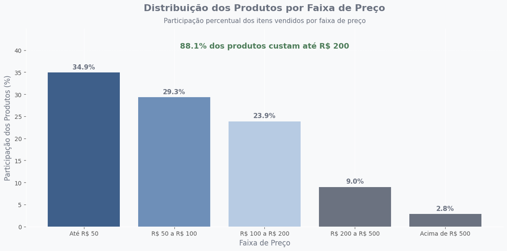

### Principais Resultados Gráfico 4.2

- 88,1% dos produtos possuem preço inferior a R$ 200.
- Apenas 2,8% dos produtos possuem preço superior a R$ 500.
- O marketplace apresenta predominância de itens de baixo e médio ticket.
- A distribuição apresenta assimetria positiva, com poucos produtos de alto valor formando a cauda superior da distribuição.

### Insight Executivo

A Olist possui um portfólio fortemente concentrado em produtos acessíveis, evidenciando uma estratégia baseada em volume de vendas e amplo alcance de consumidores. Esse perfil favorece escalabilidade e recorrência de compras, mas também indica menor participação de categorias premium com potencial de elevar o ticket médio da operação.

### Recomendação

Avaliar oportunidades de expansão em categorias de maior valor agregado, buscando aumentar o ticket médio da plataforma sem comprometer a competitividade nos segmentos responsáveis pelo maior volume de vendas.

### 4.3 – Distribuição dos Fretes por Faixa de Valor

**Problema de Negócio**

O custo de frete é um dos principais fatores que influenciam a competitividade de um marketplace e a percepção de valor pelos clientes.

**Objetivo**

Analisar a distribuição dos valores de frete cobrados nos pedidos para compreender o comportamento dos custos logísticos da operação.

**Hipótese**

A maior parte dos pedidos apresenta fretes de baixo valor, indicando uma operação logística relativamente previsível para a maioria das transações.

**Decisão Apoiada**

Avaliar a estabilidade dos custos logísticos e identificar potenciais riscos relacionados a fretes elevados que possam impactar a conversão de vendas e a satisfação dos clientes.

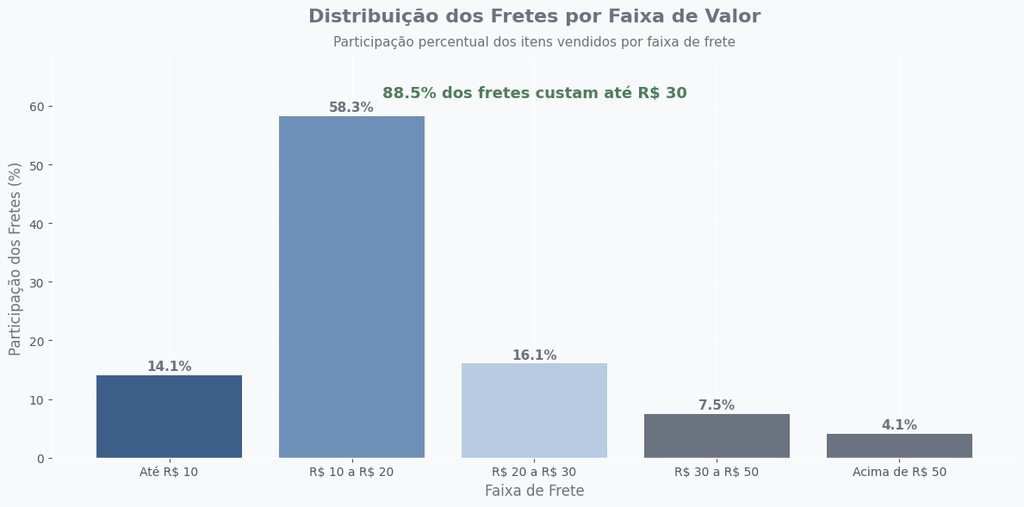

### Principais Resultados Gráfico 4.3

- A maior parte dos pedidos apresenta valores de frete concentrados nas faixas mais baixas da distribuição.
- Os fretes elevados representam uma pequena parcela da operação.
- A distribuição apresenta assimetria positiva, com poucos casos extremos concentrados nas faixas superiores, ou seja, **a maioria dos valores está concentrada nos valores mais baixos, mas existem alguns poucos casos com valores muito altos.**
- O comportamento observado indica **maior previsibilidade dos custos logísticos** em comparação à variabilidade dos preços dos produtos.

### Insight Executivo

Os resultados sugerem que a **operação logística da Olist apresenta custos relativamente estáveis para a maioria dos pedidos.** Embora existam casos de fretes significativamente superiores à média, esses eventos representam exceções dentro da operação. Essa previsibilidade contribui para maior controle operacional e reduz a exposição a oscilações relevantes nos custos de entrega.

### Recomendação

Monitorar continuamente os pedidos com fretes significativamente acima do padrão da operação, identificando possíveis concentrações por região, categoria de produto ou vendedor. A redução desses casos extremos pode contribuir para melhorar a competitividade da plataforma e a percepção de valor pelos clientes.

### 4.4 - Perfil dos Pedidos: quantidade de itens por pedido

**Problema de Negócio**

Compreender o comportamento de compra dos clientes é fundamental para identificar oportunidades de aumento de receita e eficiência operacional.

**Objetivo**

Analisar a quantidade de itens adquiridos por pedido para entender o padrão de compra dos consumidores na plataforma.

**Hipótese**

A maior parte dos pedidos é composta por apenas um item, indicando um comportamento de compra pontual e baixa consolidação de produtos em um mesmo pedido.

**Decisão Apoiada**

Avaliar oportunidades de aumento do ticket médio por meio de estratégias de cross-sell, recomendações de produtos e incentivo à compra de múltiplos itens.

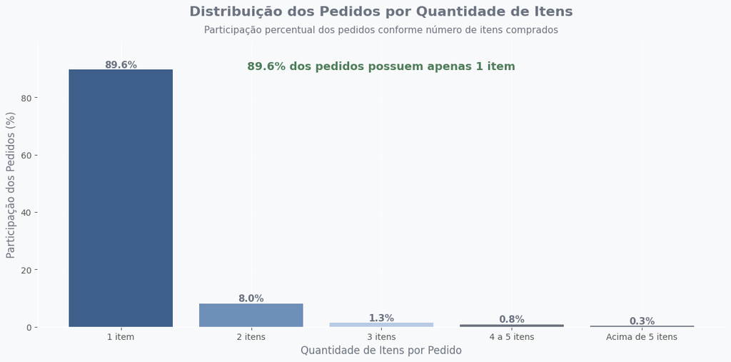

### Principais Resultados Gráfico 4.4

- A maior parte dos pedidos é composta por apenas um item.
- Pedidos com dois ou mais produtos representam parcela significativamente menor da operação.
- A distribuição apresenta forte concentração nos menores volumes de itens por pedido.
- Compras com grande quantidade de itens são eventos pouco frequentes.

### Insight Executivo

Os resultados indicam que os **clientes utilizam a plataforma principalmente para compras pontuais**, adquirindo poucos produtos por transação. Esse comportamento sugere **potencial para expansão do ticket médio por meio de iniciativas que incentivem a compra de produtos complementares e aumentem o valor de cada pedido.**

### Recomendação

**Implementar estratégias de cross-sell, recomendações personalizadas e ofertas combinadas para estimular compras com múltiplos itens.** O aumento da quantidade média de itens por pedido pode elevar a receita sem a necessidade de ampliar proporcionalmente a base de clientes.

### 4.5 – Distribuição dos Clientes por Estado

**Problema de Negócio**

Compreender a distribuição geográfica da base de clientes é fundamental para avaliar oportunidades de crescimento e possíveis riscos de concentração regional.

**Objetivo**

Identificar os estados com maior participação de clientes na plataforma e analisar a distribuição geográfica da demanda.

**Hipótese**

A maior parte dos clientes está concentrada nos estados mais populosos e economicamente relevantes do país, especialmente na região Sudeste.

**Decisão Apoiada**

Apoiar decisões relacionadas à expansão comercial, investimentos logísticos e definição de mercados prioritários para crescimento.

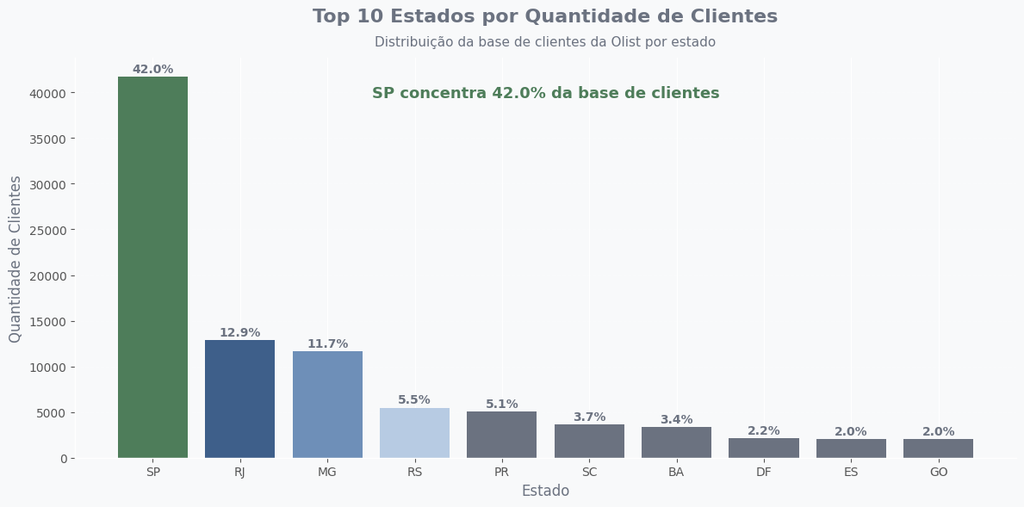

### Principais Resultados Gráfico 4.5

- São Paulo concentra aproximadamente 42% da base de clientes da Olist.
- Rio de Janeiro e Minas Gerais aparecem na sequência entre os estados com maior participação.
- A região Sudeste representa a maior concentração de clientes da plataforma.
- Estados das regiões Norte e Nordeste apresentam participação significativamente menor.

### Insight Executivo

A Olist possui forte presença nos principais centros consumidores do país, especialmente na região Sudeste. E**ssa concentração favorece ganhos de escala operacional e eficiência logística, mas também evidencia dependência relevante de poucos mercados para sustentar o volume de vendas da plataforma.**

### Recomendação

**Manter investimentos nos estados com maior concentração de clientes para preservar eficiência operacional**, enquanto avalia **estratégias de expansão em regiões com menor participação,** reduzindo riscos de concentração e ampliando o potencial de crescimento da base de consumidores.

### 4.6 – Evolução Mensal dos Pedidos

**Problema de Negócio**

Investidores precisam avaliar se a plataforma apresenta crescimento sustentável ao longo do tempo e capacidade de expansão de mercado.

**Objetivo**

Analisar a evolução mensal do volume de pedidos para identificar tendências de crescimento da operação.

**Hipótese**

O volume de pedidos apresentou crescimento ao longo do período analisado, refletindo aumento da adoção da plataforma por consumidores e vendedores.

**Decisão Apoiada**

Avaliar o potencial de crescimento do negócio, a capacidade de escala da operação e a atratividade da empresa para investimentos futuros.

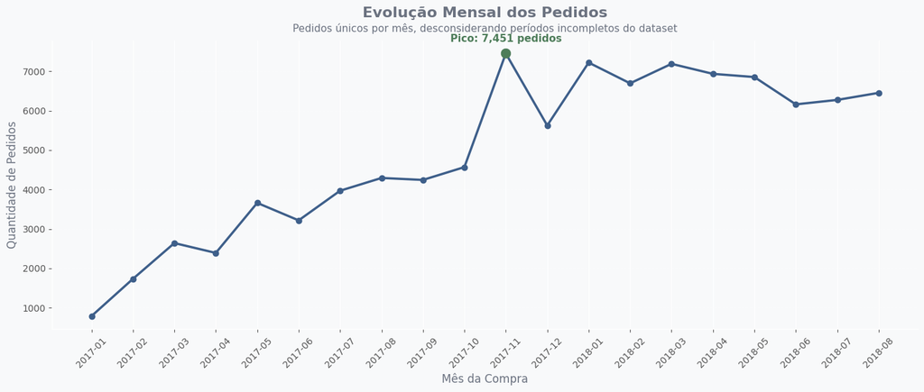

### Recomendação

Manter **investimentos em infraestrutura tecnológica, logística e experiência do cliente** para sustentar o crescimento observado. Além disso, **monitorar períodos de pico de demanda **para garantir que a expansão da operação não comprometa a qualidade dos serviços prestados.

## Conclusão da Seção 4 – Análise Descritiva do Marketplace

A análise descritiva permitiu compreender os principais aspectos da operação da Olist sob a perspectiva comercial, financeira e de mercado.

Os resultados indicaram que a plataforma possui um portfólio predominantemente composto por produtos de baixo e médio valor, caracterizando um modelo de negócio orientado a volume de vendas. Essa característica é reforçada pelo comportamento dos pedidos, que normalmente contêm apenas um item, evidenciando oportunidades futuras para aumento do ticket médio por meio de estratégias de venda cruzada e recomendação de produtos.

Sob a perspectiva geográfica, observou-se forte concentração de clientes na região Sudeste, especialmente no estado de São Paulo. Embora essa concentração contribua para ganhos de escala e eficiência operacional, ela também evidencia dependência relevante de poucos mercados consumidores, indicando oportunidades de expansão em outras regiões do país.

Dessa forma, após compreender o perfil comercial e a evolução do marketplace, a próxima etapa da análise concentra-se na operação logística, buscando avaliar se o crescimento observado foi acompanhado por níveis adequados de eficiência na entrega dos pedidos e pela manutenção da experiência dos clientes.

## 5 - Análise Operacional e Logística

## Objetivo da Seção

Esta seção analisa o desempenho operacional e logístico da Olist, avaliando indicadores relacionados aos prazos de entrega, cumprimento dos prazos prometidos e eficiência do processo de entrega aos clientes.

As análises desenvolvidas nesta etapa possuem caráter predominantemente descritivo e buscam responder à pergunta:

**Como a operação logística da plataforma se comporta?**

Serão avaliados aspectos como tempo de entrega, entregas antecipadas, atrasos e variabilidade dos prazos, permitindo compreender a qualidade operacional da experiência oferecida aos clientes.

Os resultados desta seção servirão de base para as análises de satisfação dos clientes apresentadas posteriormente, uma vez que fatores logísticos são frequentemente associados à percepção da experiência de compra.

### 5.1 - Estatísticas Descritivas do Tempo de Entrega

**Problema de Negócio**

Antes de avaliar o impacto da logística sobre a satisfação dos clientes, é necessário compreender o comportamento geral dos prazos de entrega da operação.

**Objetivo**

Analisar as principais estatísticas do tempo de entrega para identificar o prazo típico das entregas e a dispersão dos dados.

**Hipótese**

A maior parte dos pedidos é entregue dentro de um intervalo relativamente curto, enquanto uma pequena parcela apresenta prazos significativamente superiores ao padrão.

**Decisão Apoiada**

Estabelecer uma visão geral do desempenho logístico da operação e criar uma base de comparação para as análises posteriores de distribuição, outliers e satisfação dos clientes.

|  | order_id | order_purchase_timestamp | order_delivered_customer_date | tempo_entrega |
| --- | --- | --- | --- | --- |
| 0 | 00010242fe8c5a6d1ba2dd792cb16214 | 2017-09-13 08:59:02 | 2017-09-20 23:43:48 | 7.00 |
| 1 | 00018f77f2f0320c557190d7a144bdd3 | 2017-04-26 10:53:06 | 2017-05-12 16:04:24 | 16.00 |
| 2 | 000229ec398224ef6ca0657da4fc703e | 2018-01-14 14:33:31 | 2018-01-22 13:19:16 | 7.00 |
| 3 | 00024acbcdf0a6daa1e931b038114c75 | 2018-08-08 10:00:35 | 2018-08-14 13:32:39 | 6.00 |
| 4 | 00042b26cf59d7ce69dfabb4e55b4fd9 | 2017-02-04 13:57:51 | 2017-03-01 16:42:31 | 25.00 |

| index | tempo_entrega |
| --- | --- |
| quantidade | 110839.000000 |
| média | 12.012414 |
| desvio_padrão | 9.445470 |
| mínimo | 0.000000 |
| 1_quartil | 6.000000 |
| mediana | 10.000000 |
| 3_quartil | 15.000000 |
| máximo | 209.000000 |

### Principais Resultados Gráfico 5.1

- Foram identificadas 110.839 entregas com informação válida de tempo de entrega.
- O tempo médio de entrega foi de 12 dias.
- A mediana foi de 10 dias, indicando que m**etade dos pedidos foi entregue em até 10 dias.**
- **75% das entregas ocorreram em até 15 dias.**
- O maior tempo de entrega identificado foi de 209 dias.

### Insight Executivo

A análise indica que o prazo típico de entrega da Olist é relativamente concentrado: **metade dos pedidos foi entregue em até 10 dias e 75% em até 15 dias. Isso sugere um desempenho logístico consistente para a maior parte da operação.**

Entretanto, **a diferença entre o prazo típico e o valor máximo de 209 dias indica a presença de casos excepcionais muito acima do padrão**. Esses casos **não representam o comportamento geral da operação,** mas podem gerar impactos negativos relevantes na experiência do cliente.

### Recomendação

**Utilizar a mediana e os quartis como principais referências para interpretar o prazo típico de entrega,** evitando depender apenas da média. Prosseguir com a análise da distribuição dos tempos de entrega para compreender melhor a variabilidade dos prazos observados na operação.

### 5.2 Distribuição do Tempo de Entrega por Faixa

**Problema de Negócio**

Compreender apenas a média ou a mediana dos prazos de entrega não é suficiente para avaliar o desempenho logístico da operação. É necessário entender como os pedidos se distribuem entre diferentes faixas de prazo.

**Objetivo**

Analisar a distribuição dos tempos de entrega para identificar os intervalos de prazo mais frequentes na operação da Olist.

**Hipótese**

A maior parte dos pedidos está concentrada em faixas de entrega relativamente curtas, indicando consistência operacional para a maioria dos clientes.

**Decisão Apoiada**

Avaliar a previsibilidade dos prazos de entrega e identificar se a operação está concentrada em intervalos considerados competitivos para o mercado de e-commerce. .

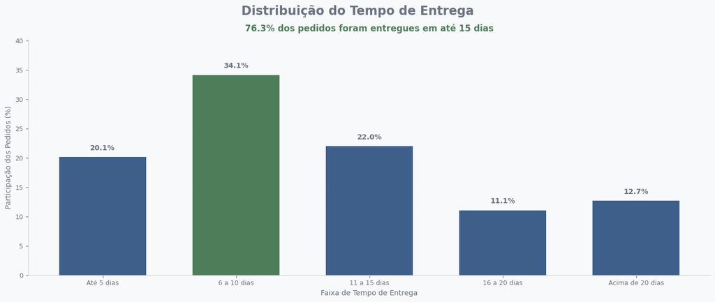

| Faixa de Tempo de Entrega | Percentual |
| --- | --- |
| Até 5 dias | 20,1% |
| 6 a 10 dias | 34,1% |
| 11 a 15 dias | 22,0% |
| 16 a 20 dias | 11,1% |
| Acima de 20 dias | 12,7% |

### Insight Executivo

A distribuição dos tempos de entrega demonstra que a operação logística da Olist apresenta **comportamento relativamente previsível** para a maioria dos pedidos. A concentração das entregas em faixas mais curtas sugere capacidade de atender grande parte dos clientes dentro de **prazos competitivos**, contribuindo para uma experiência de compra mais consistente.

### Recomendação

Utilizar a distribuição dos prazos como referência para monitoramento operacional, **acompanhando possíveis deslocamentos da concentração das entregas para faixas mais longas ao longo do tempo**. Alterações nesse comportamento podem indicar degradação da eficiência logística e impactar a satisfação dos clientes.

### 5.3 - Boxplot do Tempo de Entrega

**Problema de Negócio**

Embora as estatísticas descritivas e a distribuição dos prazos permitam compreender o comportamento geral das entregas, é necessário avaliar a dispersão dos dados e identificar possíveis ocorrências fora do padrão operacional.

**Objetivo**

Analisar a variabilidade do tempo de entrega e identificar a presença de valores extremos que possam representar riscos para a experiência do cliente.

**Hipótese**

A maior parte das entregas ocorre dentro de uma faixa relativamente estável, mas existem casos isolados com prazos significativamente superiores ao padrão observado.

**Decisão Apoiada**

Avaliar a consistência da operação logística e identificar evidências que justifiquem investigações mais aprofundadas sobre atrasos e seus impactos na satisfação dos clientes.

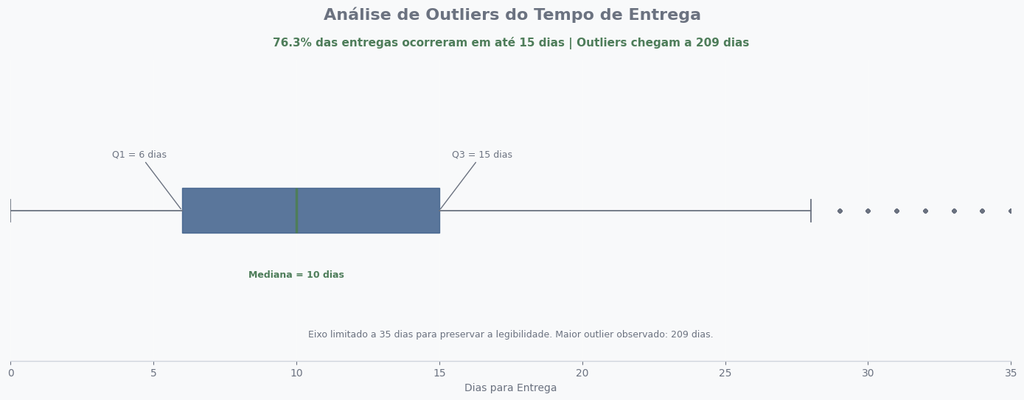

| Indicador | Valor |
| --- | --- |
| Quantidade de Entregas | 110.839 |
| Tempo Médio | 12,0 dias |
| Mediana | 10 dias |
| 1º Quartil (Q1) | 6 dias |
| 3º Quartil (Q3) | 15 dias |
| Tempo Máximo | 209 dias |

### Principais Resultados Gráfico 5.3

- O tempo mediano de entrega foi de 10 dias.
- Aproximadamente 75% das entregas ocorreram em até 15 dias.
- A maior parte dos pedidos permaneceu concentrada em uma faixa operacional relativamente estável.
- Foram identificados valores extremos significativamente acima do padrão operacional, com entregas que atingiram até 209 dias.

### Insight Executivo

Os resultados demonstram que a operação logística apresenta comportamento consistente para a maioria dos pedidos, concentrando as entregas em até 15 dias. Entretanto, a **presença de casos extremos muito acima do padrão** operacional evidencia ocorrências pontuais que **podem impactar negativamente a experiência do cliente.**

Embora representem uma pequena parcela da operação, **esses casos possuem potencial para influenciar avaliações negativas e aumentar a percepção de risco sobre a qualidade do serviço**. Dessa forma, **os outliers identificados justificam análises complementares para avaliar sua relação com os níveis de satisfação observados na plataforma.**

**O boxplot foi utilizado como visualização complementar** para evidenciar a dispersão dos dados e a presença de valores extremos no tempo de entrega. Entretanto, por se tratar de uma distribuição assimétrica e com cauda longa, ou seja, os atrasos extremos representam exceções na operação, mas possuem potencial de gerar impactos desproporcionais na experiência do cliente, o gráfico não foi adotado como visual principal da análise, pois a concentração dos dados fica comprimida pela influência dos outliers. Assim, a interpretação executiva foi apoiada principalmente pela tabela-resumo e pelo gráfico de distribuição por faixas de prazo, enquanto o boxplot foi mantido como evidência técnica dos casos fora do padrão operacional.

### Recomendação

Investigar separadamente os pedidos com prazos muito elevados para identificar possíveis causas operacionais, regionais ou relacionadas a sellers específicos. A redução desses casos extremos pode gerar ganhos relevantes na experiência do cliente sem exigir mudanças estruturais em toda a operação logística.

### Justificativa Metodológica

O boxplot foi utilizado como **visualização complementar** por permitir identificar mediana, dispersão e valores extremos dos tempos de entrega, características importantes para a análise exploratória dos dados (WILKE, 2019). Entretanto, considerando que o Tech Challenge prioriza a comunicação executiva para investidores e a clareza da mensagem, a interpretação principal foi apoiada pela tabela-resumo e pelo gráfico de distribuição por faixas de prazo, mais intuitivos para esse público (KNAFLIC, 2015; FIAP, 2025).

### Conclusão da Seção 5 – Análise Descritiva da Logística

A análise descritiva da logística permitiu compreender o comportamento geral dos prazos de entrega da Olist e avaliar a consistência operacional da plataforma.

Os resultados demonstraram que a maior parte dos pedidos foi entregue dentro de prazos relativamente curtos e previsíveis, com mediana de 10 dias e concentração significativa das entregas em até 15 dias. Esse comportamento indica que a operação logística atende adequadamente a maioria dos clientes e apresenta estabilidade para grande parte dos pedidos analisados.

Entretanto, também foram identificados casos extremos com tempos de entrega significativamente superiores ao padrão observado. Embora representem uma pequena parcela da operação, esses eventos possuem potencial para impactar negativamente a percepção de qualidade do serviço e a experiência dos consumidores.

Sob a perspectiva de investidores, **os resultados sugerem que a Olist possui uma operação logística consistente e capaz de sustentar o crescimento observado** na seção anterior. No entanto, a presença de entregas fora do padrão evidencia **oportunidades de melhoria operacional que podem gerar ganhos adicionais de satisfação, retenção de clientes e eficiência do marketplace.**

Dessa forma, após compreender o comportamento geral dos prazos de entrega, a próxima etapa da análise busca investigar como o desempenho logístico influencia a experiência do cliente, explorando relações entre lead time, atrasos e níveis de satisfação observados na plataforma.

# 6. Desempenho Comercial

## Objetivo da Seção

Esta seção analisa o desempenho comercial da Olist por meio da evolução da receita, do ticket médio, da participação das categorias, da distribuição regional do faturamento e do desempenho dos principais sellers.

As análises desenvolvidas possuem caráter predominantemente descritivo e buscam responder à pergunta:

**Como o marketplace gera receita e como esse desempenho evoluiu ao longo do tempo?**

Serão avaliados indicadores financeiros e comerciais que permitem compreender o crescimento da plataforma, a composição do faturamento e os principais fatores associados à geração de receita.

Os resultados desta seção fornecem evidências sobre a capacidade de crescimento do negócio e subsidiam a avaliação de oportunidades e riscos para investidores.

### 6.0 - Preparação da Base de Receita por Item

**Problema de Negócio**

As análises de receita precisam considerar corretamente todos os itens vendidos, sem duplicar valores por causa de múltiplas avaliações ou perder itens de pedidos com mais de um produto.

**Objetivo**

Criar uma base deduplicada no nível item do pedido para sustentar as análises comerciais da Seção 6.

**Hipótese**

A utilização de uma base no nível item do pedido melhora a consistência dos cálculos de receita, ticket médio, categorias, estados e sellers.

**Decisão Apoiada**

Garantir que os indicadores comerciais utilizados no relatório executivo sejam calculados com granularidade adequada e consistência metodológica.

```
============================================================
VALIDAÇÃO DA BASE DE RECEITA POR ITEM
============================================================
Linhas na base_satisfacao original : 113,314
Linhas na base_receita_item        : 105,031
Pedidos únicos                     : 91,901
Sellers únicos                     : 2,913
Receita total analisada            : R$ 12,687,026.45
Período analisado                  : 2017-01 a 2018-07
============================================================
```

| indicador | valor |
| --- | --- |
| Linhas na base_receita_item | 105.031 |
| Quantidade de colunas | 39 |
| Pedidos únicos | 91.901 |
| Sellers únicos | 2.913 |
| Receita total analisada | R$ 12.687.026,45 |

| order_id | order_item_id | seller_id | price |
| --- | --- | --- | --- |
| 00010242fe8c5a6d1ba2dd792cb16214 | 1 | 48436dade18ac8b2bce089ec2a041202 | 58.900000 |
| 00018f77f2f0320c557190d7a144bdd3 | 1 | dd7ddc04e1b6c2c614352b383efe2d36 | 239.900000 |
| 000229ec398224ef6ca0657da4fc703e | 1 | 5b51032eddd242adc84c38acab88f23d | 199.000000 |
| 00042b26cf59d7ce69dfabb4e55b4fd9 | 1 | df560393f3a51e74553ab94004ba5c87 | 199.900000 |
| 00048cc3ae777c65dbb7d2a0634bc1ea | 1 | 6426d21aca402a131fc0a5d0960a3c90 | 21.900000 |
| 00054e8431b9d7675808bcb819fb4a32 | 1 | 7040e82f899a04d1b434b795a43b4617 | 19.900000 |
| 000576fe39319847cbb9d288c5617fa6 | 1 | 5996cddab893a4652a15592fb58ab8db | 810.000000 |
| 0005a1a1728c9d785b8e2b08b904576c | 1 | a416b6a846a11724393025641d4edd5e | 145.950000 |
| 0005f50442cb953dcd1d21e1fb923495 | 1 | ba143b05f0110f0dc71ad71b4466ce92 | 53.990000 |
| 00061f2a7bc09da83e415a52dc8a4af1 | 1 | cc419e0650a3c5ba77189a1882b7556a | 59.990000 |
| 00063b381e2406b52ad429470734ebd5 | 1 | 8602a61d680a10a82cceeeda0d99ea3d | 45.000000 |
| 0006ec9db01a64e59a68b2c340bf65a7 | 1 | 4a3ca9315b744ce9f8e9374361493884 | 74.000000 |
| 0008288aa423d2a3f00fcb17cd7d8719 | 1 | 1f50f920176fa81dab994f9023523100 | 49.900000 |
| 0008288aa423d2a3f00fcb17cd7d8719 | 2 | 1f50f920176fa81dab994f9023523100 | 49.900000 |
| 0009c9a17f916a706d71784483a5d643 | 1 | fcb5ace8bcc92f75707dc0f01a27d269 | 639.000000 |
| 000aed2e25dbad2f9ddb70584c5a2ded | 1 | fe2032dab1a61af8794248c8196565c9 | 144.000000 |
| 000c3e6612759851cc3cbb4b83257986 | 1 | 218d46b86c1881d022bce9c68a7d4b15 | 99.000000 |
| 000e562887b1f2006d75e0be9558292e | 1 | 8cbac7e12637ed9cffa18c7875207478 | 25.000000 |
| 000e63d38ae8c00bbcb5a30573b99628 | 1 | 1c129092bf23f28a5930387c980c0dfc | 47.900000 |
| 000e906b789b55f64edcb1f84030f90d | 1 | ea8482cd71df3c1969d7b9473ff13abc | 21.990000 |

### Resultado da Preparação da Base de Receita

A base `base_receita_item` foi criada para sustentar as análises comerciais da Seção 6, considerando a granularidade de item do pedido.

Essa estrutura permite calcular receita, ticket médio, participação por categoria, participação por estado e desempenho de sellers sem duplicar valores por múltiplas avaliações e sem perder itens de pedidos compostos por mais de um produto.

Dessa forma, a Seção 6 passa a utilizar uma base metodologicamente mais adequada para análises de desempenho comercial.

### 6.1 - Evolução Mensal da Receita

**Problema de Negócio**

Investidores precisam compreender se a Olist apresentou crescimento consistente na geração de receita ao longo do período analisado.

**Objetivo**

Analisar a evolução mensal da receita gerada pela venda de produtos na plataforma, utilizando a base deduplicada no nível item do pedido.

**Hipótese**

A receita mensal apresentou crescimento ao longo do período analisado, refletindo a expansão comercial da plataforma e o aumento do volume transacionado.

**Decisão Apoiada**

Avaliar a capacidade da Olist de gerar valor financeiro e sustentar crescimento comercial ao longo do tempo.

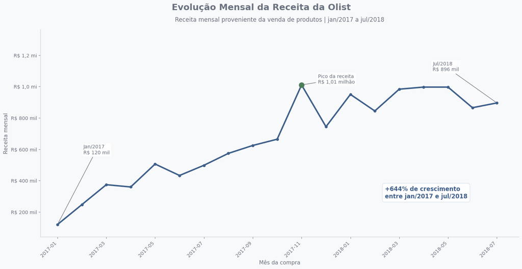

| ano_mes | receita_total | pedidos |
| --- | --- | --- |
| 2017-01 | 120312.870000 | 789 |
| 2017-02 | 247303.020000 | 1733 |
| 2017-03 | 374344.300000 | 2641 |
| 2017-04 | 359927.230000 | 2391 |
| 2017-05 | 506071.140000 | 3660 |
| 2017-06 | 433038.600000 | 3217 |
| 2017-07 | 498031.480000 | 3969 |
| 2017-08 | 573971.680000 | 4293 |
| 2017-09 | 624401.690000 | 4243 |
| 2017-10 | 664219.430000 | 4568 |
| 2017-11 | 1010271.370000 | 7451 |
| 2017-12 | 743914.170000 | 5624 |
| 2018-01 | 950030.360000 | 7220 |
| 2018-02 | 844178.710000 | 6694 |
| 2018-03 | 983213.440000 | 7188 |
| 2018-04 | 996647.750000 | 6934 |
| 2018-05 | 996517.680000 | 6853 |
| 2018-06 | 865124.310000 | 6160 |
| 2018-07 | 895507.220000 | 6273 |

### Principais Resultados Gráfico 6.1

- A **receita mensal apresentou crescimento expressivo** entre jan/2017 e jul/2018.
- O faturamento evoluiu de aproximadamente **R$ 120 mil em jan/2017 para R$ 896 mil em jul/2018**.
- O **pico de receita ocorreu em nov/2017**, atingindo aproximadamente **R$ 1,01 milhão**.
- A receita acumulou **crescimento de aproximadamente 644%** no período analisado.
- Apesar de oscilações pontuais, a trajetória geral demonstra **forte expansão comercial da plataforma**.

### Insight Executivo

A evolução da receita demonstra que a Olist passou por uma fase de forte expansão comercial, ampliando significativamente sua capacidade de geração de valor. O comportamento da série sugere crescimento sustentado do marketplace, com aumento relevante do volume financeiro transacionado ao longo do tempo.

### Recomendação

Analisar em conjunto o comportamento do ticket médio e do volume de pedidos para identificar os principais fatores responsáveis pelo crescimento da receita. Essa avaliação permitirá verificar se a expansão ocorreu principalmente por ganho de escala operacional, aumento do valor médio das compras ou pela combinação de ambos.

### 6.2 - Evolução Mensal do Ticket Médio

**Problema de Negócio**

Investidores precisam entender se o crescimento da receita foi impulsionado pelo aumento do valor médio das compras ou principalmente pelo crescimento do volume de pedidos.

**Objetivo**

Analisar a evolução mensal do ticket médio, verificando se houve aumento, estabilidade ou redução no valor médio dos pedidos ao longo do período analisado.

**Hipótese**

O ticket médio apresentou comportamento relativamente estável quando comparado ao crescimento da receita, indicando que a expansão comercial ocorreu principalmente pelo aumento do volume de pedidos.

**Decisão Apoiada**

Avaliar se o crescimento da Olist está associado ao ganho de escala operacional ou ao aumento do valor médio transacionado por pedido.

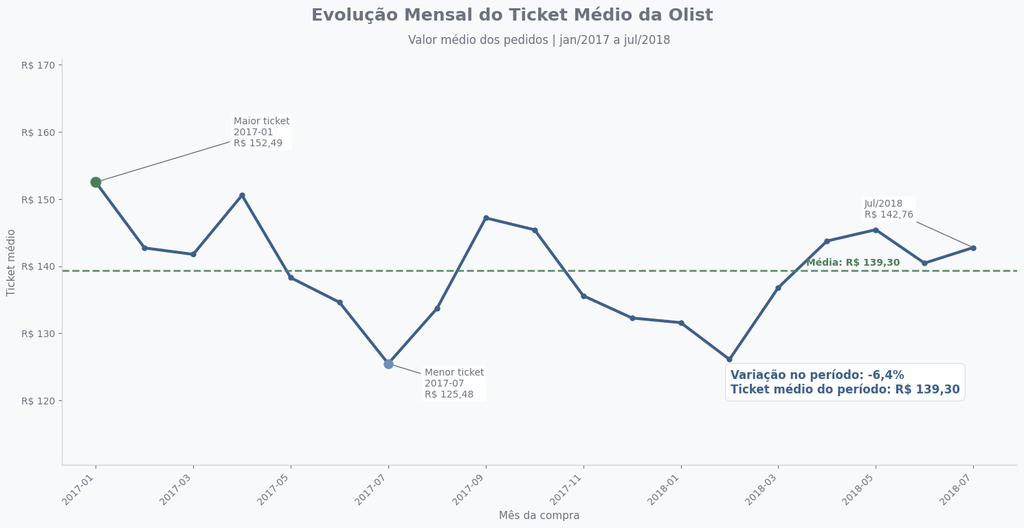

| ano_mes | receita_total | pedidos | ticket_medio |
| --- | --- | --- | --- |
| 2017-01 | 120312.870000 | 789 | 152.490000 |
| 2017-02 | 247303.020000 | 1733 | 142.700000 |
| 2017-03 | 374344.300000 | 2641 | 141.740000 |
| 2017-04 | 359927.230000 | 2391 | 150.530000 |
| 2017-05 | 506071.140000 | 3660 | 138.270000 |
| 2017-06 | 433038.600000 | 3217 | 134.610000 |
| 2017-07 | 498031.480000 | 3969 | 125.480000 |
| 2017-08 | 573971.680000 | 4293 | 133.700000 |
| 2017-09 | 624401.690000 | 4243 | 147.160000 |
| 2017-10 | 664219.430000 | 4568 | 145.410000 |
| 2017-11 | 1010271.370000 | 7451 | 135.590000 |
| 2017-12 | 743914.170000 | 5624 | 132.270000 |
| 2018-01 | 950030.360000 | 7220 | 131.580000 |
| 2018-02 | 844178.710000 | 6694 | 126.110000 |
| 2018-03 | 983213.440000 | 7188 | 136.790000 |
| 2018-04 | 996647.750000 | 6934 | 143.730000 |
| 2018-05 | 996517.680000 | 6853 | 145.410000 |
| 2018-06 | 865124.310000 | 6160 | 140.440000 |
| 2018-07 | 895507.220000 | 6273 | 142.760000 |

### Principais Resultados Gráfico 6.2

- O **ticket médio apresentou relativa estabilidade ao longo do período analisado**.
- O **maior ticket médio ocorreu em jan/2017**, atingindo aproximadamente **R$ 152,49 por pedido**.
- O **menor ticket médio foi observado em jul/2017**, com aproximadamente **R$ 125,48 por pedido**.
- Em jul/2018, o ticket médio atingiu **R$ 142,76**, representando uma variação de aproximadamente **-6,4%** em relação ao início da série.
- O ticket médio médio do período foi de aproximadamente **R$ 139,30**.

### Insight Executivo

Apesar do forte crescimento da receita observado no gráfico anterior, o ticket médio permaneceu relativamente estável durante o período analisado. Esse comportamento sugere que o crescimento da Olist foi impulsionado principalmente pelo aumento do volume de pedidos e da base de clientes, e não pelo aumento do valor médio gasto em cada compra.

### Recomendação

Monitorar conjuntamente receita, volume de pedidos e ticket médio para diferenciar crescimento por escala de crescimento por valor transacionado. Os resultados indicam que a estratégia de expansão da Olist esteve fortemente associada ao ganho de escala operacional, característica típica de marketplaces em fase de crescimento.

### 6.3 - Participação da Receita por Categoria

**Problema de Negócio**

Investidores precisam identificar quais categorias de produtos concentram maior geração de receita dentro do marketplace.

**Objetivo**

Analisar a participação das principais categorias na receita total da Olist, identificando os segmentos mais relevantes para o desempenho comercial da plataforma.

**Hipótese**

A receita da Olist está concentrada em um grupo limitado de categorias, indicando que alguns segmentos possuem maior relevância estratégica para o crescimento comercial.

**Decisão Apoiada**

Priorizar categorias com maior potencial de receita em estratégias comerciais, aquisição de sellers, marketing e expansão do marketplace.

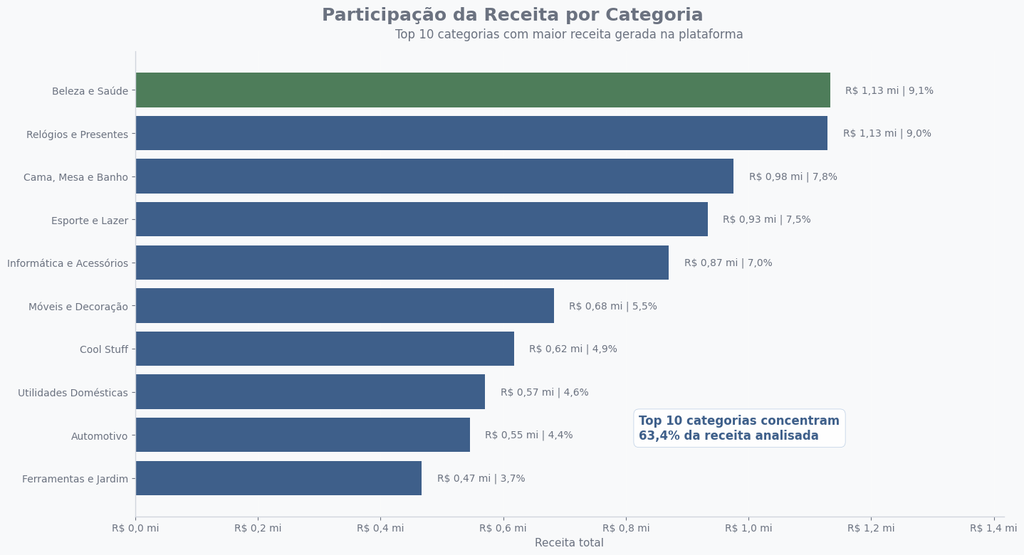

| categoria_executiva | receita_total | participacao_receita | pedidos |
| --- | --- | --- | --- |
| Beleza e Saúde | 1133189.920000 | 9.100000 | 8013 |
| Relógios e Presentes | 1129368.380000 | 9.000000 | 5227 |
| Cama, Mesa e Banho | 975473.810000 | 7.800000 | 8854 |
| Esporte e Lazer | 933215.170000 | 7.500000 | 7265 |
| Informática e Acessórios | 870261.070000 | 7.000000 | 6287 |
| Móveis e Decoração | 682501.560000 | 5.500000 | 6053 |
| Cool Stuff | 617825.270000 | 4.900000 | 3504 |
| Utilidades Domésticas | 570758.920000 | 4.600000 | 5313 |
| Automotivo | 545505.970000 | 4.400000 | 3534 |
| Ferramentas e Jardim | 467464.240000 | 3.700000 | 3391 |

### Principais Resultados Gráfico 6.3

- As **10 categorias com maior faturamento concentraram 63,4% da receita analisada**.
- **Beleza e Saúde** foi a categoria líder, representando aproximadamente **9,1% da receita total**.
- Relógios e Presentes e Cama, Mesa e Banho aparecem na sequência, com participações de **9,0%** e **7,8%**, respectivamente.
- Nenhuma categoria individual ultrapassou **10% da receita total da plataforma**.
- A distribuição da receita demonstra **concentração moderada**, porém sem dependência excessiva de uma única categoria.

### Insight Executivo

A geração de receita da Olist está distribuída entre diversas categorias relevantes, com destaque para **Beleza e Saúde**, **Relógios e Presentes** e **Cama, Mesa e Banho**. Embora as dez principais categorias concentrem aproximadamente dois terços da receita, nenhuma domina isoladamente o faturamento da plataforma, indicando um portfólio relativamente diversificado e menos exposto ao risco de concentração em um único segmento.

### Recomendação

Priorizar ações comerciais e de expansão nas categorias líderes, aproveitando segmentos já consolidados para acelerar o crescimento da receita. Paralelamente, monitorar categorias intermediárias para ampliar a diversificação do faturamento e reduzir riscos de concentração no longo prazo.

### 6.4 - Participação da Receita por Estado

**Problema de Negócio**

Investidores precisam compreender em quais estados a receita da Olist está mais concentrada e se existe dependência relevante de poucos mercados regionais.

**Objetivo**

Analisar a distribuição da receita por estado do cliente, identificando os principais mercados responsáveis pela geração de faturamento da plataforma.

**Hipótese**

A receita da Olist está concentrada principalmente nos estados mais populosos e economicamente relevantes do país, especialmente na região Sudeste.

**Decisão Apoiada**

Orientar decisões de expansão regional, investimentos logísticos e estratégias comerciais voltadas para mercados com maior potencial de crescimento.

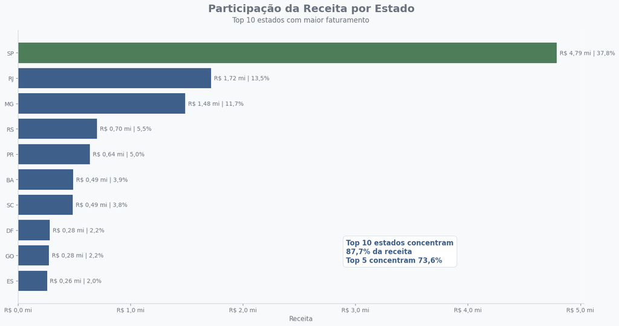

| customer_state | receita_total | participacao | pedidos |
| --- | --- | --- | --- |
| SP | 4791485.740000 | 37.800000 | 38046 |
| RJ | 1717083.240000 | 13.500000 | 11971 |
| MG | 1484760.400000 | 11.700000 | 10800 |
| RS | 703020.800000 | 5.500000 | 5112 |
| PR | 639763.040000 | 5.000000 | 4647 |
| BA | 488609.100000 | 3.900000 | 3190 |
| SC | 485824.450000 | 3.800000 | 3399 |
| DF | 281618.540000 | 2.200000 | 1975 |
| GO | 275543.670000 | 2.200000 | 1881 |
| ES | 257509.480000 | 2.000000 | 1916 |

[figure not shown]

[output not shown]

### Principais Resultados Gráfico 6.4

- **São Paulo concentra 37,8% da receita total analisada**, consolidando-se como o principal mercado da plataforma.
- Rio de Janeiro (13,5%) e Minas Gerais (11,7%) aparecem na sequência, formando com São Paulo os três estados mais relevantes em geração de receita.
- **Os 5 principais estados concentram 73,6% da receita**, enquanto os 10 principais concentram 87,7%.
- Observa-se forte concentração do faturamento na região Sudeste, especialmente em São Paulo.
- A distribuição da receita demonstra dependência relevante de poucos mercados regionais.

### Insight Executivo

A geração de receita da Olist apresenta elevada concentração geográfica, com destaque para São Paulo, responsável por mais de um terço do faturamento analisado. Embora essa concentração reflita a relevância econômica da região Sudeste, ela também evidencia uma dependência significativa de poucos mercados. Para investidores, esse comportamento sugere oportunidades de expansão em regiões com menor participação relativa, reduzindo riscos de concentração e ampliando o potencial de crescimento da plataforma.

### Recomendação

Priorizar estratégias de expansão comercial e aquisição de sellers em estados fora do eixo principal de faturamento, buscando ampliar a presença regional da plataforma. Paralelamente, manter investimentos nos mercados líderes para preservar a geração de receita enquanto se reduz gradualmente a dependência de poucos estados.

### 6.5 - Top Sellers por Receita

**Problema de Negócio**

Investidores precisam identificar se a receita da Olist depende de poucos sellers ou se está distribuída entre diversos vendedores da plataforma.

**Objetivo**

Analisar os sellers com maior geração de receita, avaliando o nível de concentração do faturamento entre os principais vendedores do marketplace.

**Hipótese**

A receita está parcialmente concentrada em um grupo reduzido de sellers, indicando a existência de vendedores estratégicos para o desempenho comercial da plataforma.

**Decisão Apoiada**

Apoiar decisões relacionadas à retenção, desenvolvimento e expansão da base de sellers, reduzindo riscos de dependência comercial e fortalecendo o ecossistema do marketplace.

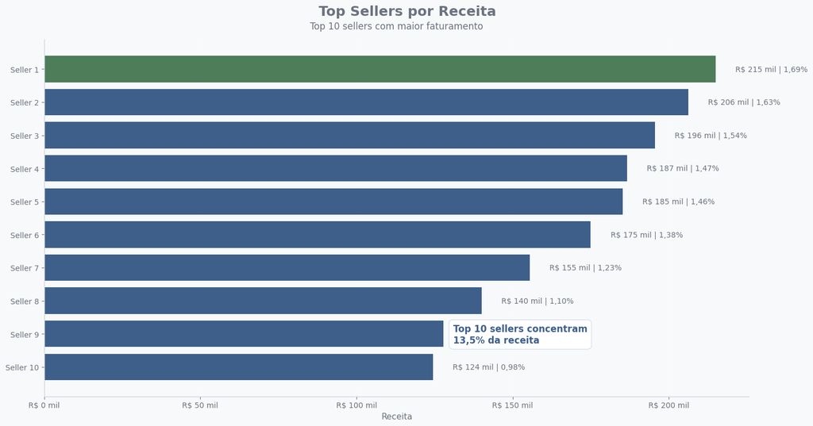

| seller_label | receita_total | participacao | pedidos |
| --- | --- | --- | --- |
| Seller 1 | 215043.230000 | 1.694985 | 1049 |
| Seller 2 | 206338.050000 | 1.626370 | 304 |
| Seller 3 | 195542.520000 | 1.541279 | 1757 |
| Seller 4 | 186624.120000 | 1.470984 | 973 |
| Seller 5 | 185327.230000 | 1.460762 | 553 |
| Seller 6 | 175032.870000 | 1.379621 | 335 |
| Seller 7 | 155437.590000 | 1.225170 | 1256 |
| Seller 8 | 140092.710000 | 1.104220 | 1142 |
| Seller 9 | 127867.130000 | 1.007857 | 1220 |
| Seller 10 | 124496.360000 | 0.981289 | 505 |

### Principais Resultados Gráfico 6.5

- O seller com maior faturamento representa aproximadamente **1,69% da receita total analisada**.
- Os **10 maiores sellers concentram apenas 13,5% da receita da plataforma**.
- Nenhum seller individual possui participação superior a 2% do faturamento total.
- A distribuição da receita entre sellers é altamente pulverizada.
- Os resultados indicam baixa dependência comercial de vendedores específicos.

### Insight Executivo

Diferentemente da concentração observada em alguns estados e categorias, a receita da Olist apresenta forte diversificação entre sellers. A baixa participação individual dos maiores vendedores demonstra que o marketplace possui um ecossistema distribuído, reduzindo riscos operacionais e comerciais associados à perda de sellers estratégicos.

### Recomendação

Manter estratégias de aquisição e retenção de sellers, preservando o elevado nível de diversificação observado. A continuidade desse modelo reduz riscos de concentração e fortalece a sustentabilidade do crescimento da plataforma no longo prazo.

### 6.6 - Crescimento Comparado: Receita, Pedidos e Ticket Médio

**Problema de Negócio**

Investidores precisam compreender se o crescimento comercial foi impulsionado pelo aumento do volume de pedidos ou pela elevação do ticket médio.

**Objetivo**

Comparar a evolução mensal da receita, dos pedidos e do ticket médio em índice base 100.

**Hipótese**

O crescimento da receita foi impulsionado principalmente pelo aumento do volume de pedidos.

**Decisão Apoiada**

Avaliar se a expansão comercial ocorreu por ganho de escala operacional ou aumento do valor médio das compras.

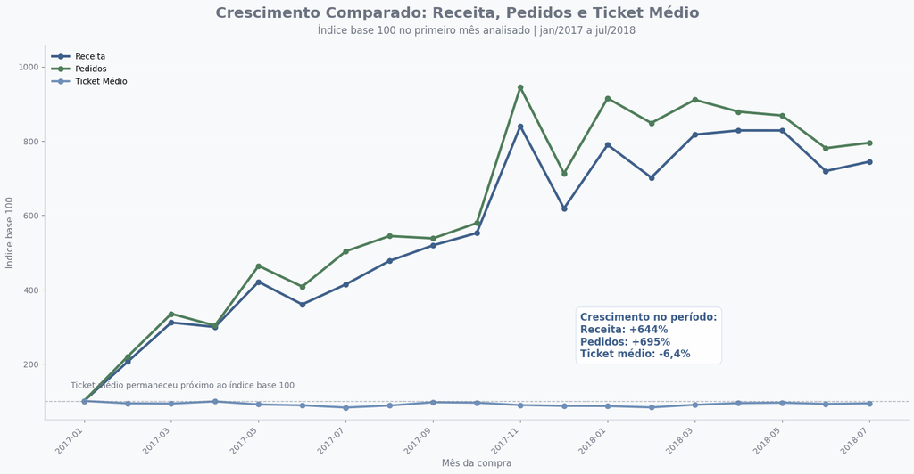

| ano_mes | receita_total | pedidos | ticket_medio | indice_receita | indice_pedidos | indice_ticket |
| --- | --- | --- | --- | --- | --- | --- |
| 2017-01 | 120312.870000 | 789 | 152.490000 | 100.000000 | 100.000000 | 100.000000 |
| 2017-02 | 247303.020000 | 1733 | 142.700000 | 205.550000 | 219.650000 | 93.580000 |
| 2017-03 | 374344.300000 | 2641 | 141.740000 | 311.140000 | 334.730000 | 92.950000 |
| 2017-04 | 359927.230000 | 2391 | 150.530000 | 299.160000 | 303.040000 | 98.720000 |
| 2017-05 | 506071.140000 | 3660 | 138.270000 | 420.630000 | 463.880000 | 90.680000 |
| 2017-06 | 433038.600000 | 3217 | 134.610000 | 359.930000 | 407.730000 | 88.280000 |
| 2017-07 | 498031.480000 | 3969 | 125.480000 | 413.950000 | 503.040000 | 82.290000 |
| 2017-08 | 573971.680000 | 4293 | 133.700000 | 477.070000 | 544.110000 | 87.680000 |
| 2017-09 | 624401.690000 | 4243 | 147.160000 | 518.980000 | 537.770000 | 96.510000 |
| 2017-10 | 664219.430000 | 4568 | 145.410000 | 552.080000 | 578.960000 | 95.360000 |
| 2017-11 | 1010271.370000 | 7451 | 135.590000 | 839.700000 | 944.360000 | 88.920000 |
| 2017-12 | 743914.170000 | 5624 | 132.270000 | 618.320000 | 712.800000 | 86.740000 |
| 2018-01 | 950030.360000 | 7220 | 131.580000 | 789.630000 | 915.080000 | 86.290000 |
| 2018-02 | 844178.710000 | 6694 | 126.110000 | 701.650000 | 848.420000 | 82.700000 |
| 2018-03 | 983213.440000 | 7188 | 136.790000 | 817.210000 | 911.030000 | 89.700000 |
| 2018-04 | 996647.750000 | 6934 | 143.730000 | 828.380000 | 878.830000 | 94.260000 |
| 2018-05 | 996517.680000 | 6853 | 145.410000 | 828.270000 | 868.570000 | 95.360000 |
| 2018-06 | 865124.310000 | 6160 | 140.440000 | 719.060000 | 780.740000 | 92.100000 |
| 2018-07 | 895507.220000 | 6273 | 142.760000 | 744.320000 | 795.060000 | 93.620000 |

### Principais Resultados Gráfico 6.6

- A **receita apresentou crescimento de aproximadamente 644%** entre jan/2017 e jul/2018.
- O **volume de pedidos cresceu cerca de 695%**, superando o crescimento da receita.
- O **ticket médio permaneceu relativamente estável**, encerrando o período com variação aproximada de **-6,4%**.
- A trajetória da receita acompanhou de forma próxima a evolução do volume de pedidos.
- Os resultados indicam que o crescimento comercial foi impulsionado principalmente pelo ganho de escala operacional.

### Insight Executivo

A expansão da Olist ocorreu principalmente por meio do aumento da quantidade de pedidos processados na plataforma e não pelo aumento do valor médio das compras. Esse comportamento é típico de marketplaces em fase de crescimento, que ampliam sua base de clientes, sellers e transações para sustentar a expansão da receita.

### Recomendação

Continuar monitorando conjuntamente receita, pedidos e ticket médio para diferenciar crescimento por escala de crescimento por valor. Os resultados sugerem que futuras iniciativas de expansão devem focar na ampliação da base transacional e na eficiência operacional, mantendo o ticket médio em níveis sustentáveis.

## Conclusão da Seção – Desempenho Comercial

### Principais Resultados

- A Olist apresentou **crescimento expressivo da receita**, que evoluiu aproximadamente **644% entre jan/2017 e jul/2018**.
- O crescimento observado foi impulsionado principalmente pelo **aumento do volume de pedidos**, uma vez que o ticket médio permaneceu relativamente estável ao longo do período.
- As **10 principais categorias concentraram 63,4% da receita**, indicando concentração moderada, porém sem dependência excessiva de um único segmento.
- Os **10 principais estados concentraram 87,7% da receita**, evidenciando forte concentração geográfica, especialmente na região Sudeste.
- Os **10 maiores sellers responderam por apenas 13,5% da receita total**, demonstrando elevada pulverização da base de vendedores.
- Nenhum seller individual representou mais de 2% do faturamento da plataforma, reduzindo riscos de dependência comercial.

### Insight Executivo

Os resultados demonstram que a Olist opera como um marketplace escalável e diversificado. O crescimento da receita foi sustentado principalmente pela expansão da operação e do volume transacionado, e não pelo aumento do valor médio gasto por pedido. Embora exista concentração relevante em determinadas regiões e categorias, a plataforma apresenta baixa dependência de sellers específicos, característica que aumenta a resiliência do modelo de negócio e reduz riscos operacionais para investidores.

### Recomendação

Para sustentar o crescimento no longo prazo, recomenda-se:

- Expandir a atuação em estados com menor participação relativa na receita, reduzindo a concentração geográfica observada.
- Fortalecer as categorias líderes, mantendo o foco nos segmentos que já demonstram elevada capacidade de geração de receita.
- Continuar ampliando a base de sellers, preservando o elevado nível de diversificação identificado.
- Monitorar continuamente receita, volume de pedidos e ticket médio para avaliar a sustentabilidade do crescimento e identificar novas oportunidades de expansão comercial.

## 7 - Perfil da Satisfação dos Clientes

## Objetivo da Seção

Após compreender o comportamento operacional e comercial da Olist, esta seção apresenta uma visão geral da satisfação dos clientes a partir das avaliações registradas na plataforma.

As análises desenvolvidas possuem caráter predominantemente descritivo e buscam responder à pergunta:

**Como os clientes avaliam a experiência de compra na Olist?**

Serão exploradas a distribuição das avaliações e as diferenças observadas entre categorias e regiões, permitindo compreender o perfil geral da satisfação antes da investigação dos fatores que a influenciam.

Os resultados desta seção servirão de base para a análise dos drivers de satisfação apresentada na seção seguinte.

### 7.1 - Distribuição das Avaliações dos Clientes

**Problema de Negócio**

Investidores precisam compreender como os clientes avaliam a experiência de compra na plataforma e se a satisfação observada representa uma vantagem competitiva para o negócio.

**Objetivo**

Analisar a distribuição das notas atribuídas pelos clientes, identificando padrões predominantes de satisfação e possíveis sinais de insatisfação.

**Hipótese**

A maior parte das avaliações concentra-se nas notas mais elevadas, indicando percepção positiva da experiência de compra.

**Decisão Apoiada**

Avaliar o nível geral de satisfação dos clientes e identificar potenciais riscos relacionados à experiência oferecida pela plataforma.

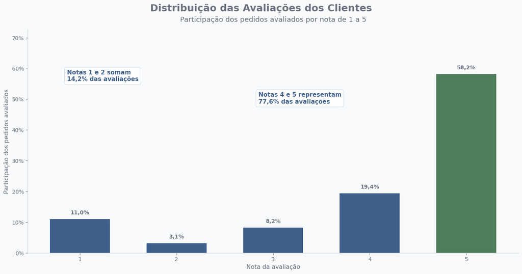

| nota | percentual |
| --- | --- |
| 1 | 11.000000 |
| 2 | 3.100000 |
| 3 | 8.200000 |
| 4 | 19.400000 |
| 5 | 58.200000 |

### Principais Resultados Gráfico 7.1

- **58,2% das avaliações receberam nota 5**, representando a maior concentração de respostas dos clientes.
- As notas **4 e 5 somam 77,6% das avaliações**, indicando predominância de experiências positivas na plataforma.
- As avaliações negativas (notas 1 e 2) representam apenas **14,2% do total**.
- A nota 4 corresponde a **19,4% das avaliações**, reforçando a concentração de percepções favoráveis.
- A distribuição das notas apresenta forte assimetria positiva, com predominância das avaliações mais altas.

### Insight Executivo

A distribuição das avaliações demonstra que a Olist manteve um elevado nível de satisfação dos clientes durante o período analisado. A forte concentração de notas 4 e 5 sugere que a experiência de compra atendeu ou superou as expectativas da maioria dos consumidores, constituindo um ativo importante para a retenção de clientes e para a reputação do marketplace.

### Recomendação

Manter o monitoramento contínuo das avaliações e aprofundar a investigação dos fatores que diferenciam pedidos com notas altas e baixas. A próxima etapa da análise deve identificar os principais drivers de satisfação, avaliando a influência de fatores como prazo de entrega, antecipação da entrega, valor do frete e características dos pedidos.

### 7.2 - Avaliação Média por Estado

**Problema de Negócio**

Diferenças regionais na satisfação podem indicar oportunidades de melhoria operacional e comercial em mercados específicos.

**Objetivo**

Analisar a nota média das avaliações por estado, identificando regiões com melhor e pior percepção da experiência de compra.

**Hipótese**

Estados com melhor desempenho operacional tendem a apresentar avaliações médias mais elevadas.

**Decisão Apoiada**

Priorizar ações de melhoria em regiões com desempenho inferior e identificar mercados com maior potencial de fidelização.

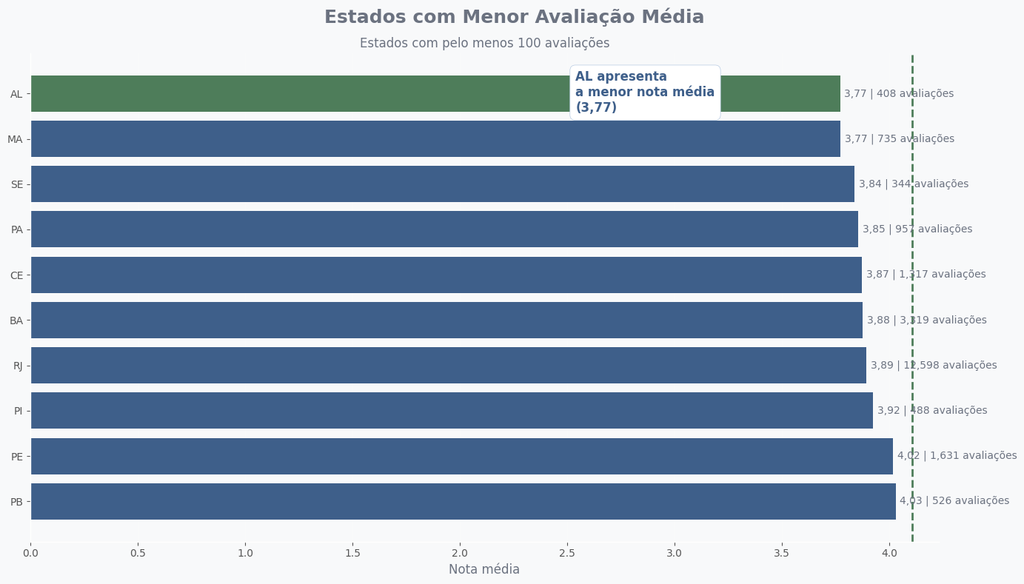

### Principais Resultados Gráfico 7.2

- **Alagoas (AL) apresentou a menor avaliação média entre os estados analisados, com nota de 3,77**, considerando apenas estados com pelo menos 100 avaliações.
- Maranhão (MA) também registrou nota média de **3,77**, seguido por Sergipe (SE), com **3,84**.
- Estados com grande volume de avaliações, como **Rio de Janeiro (RJ)**, aparecem entre os menores desempenhos, registrando nota média de **3,89** em mais de **12 mil avaliações**.
- A diferença entre o pior estado (AL) e o melhor estado dentro deste grupo (PB) foi de aproximadamente **0,26 ponto**.
- Os resultados indicam que a satisfação dos clientes apresenta variações regionais relevantes, embora nenhuma região apresente desempenho extremamente distante das demais.

### Insight Executivo

As diferenças observadas entre os estados sugerem que a experiência do cliente não é homogênea em todo o território nacional. A presença de estados com elevado volume de avaliações entre os menores desempenhos, como o Rio de Janeiro, indica que fatores operacionais, logísticos ou estruturais podem estar influenciando a percepção dos clientes em determinadas regiões. Entretanto, a amplitude relativamente pequena entre as notas demonstra que a satisfação geral da plataforma permanece consistente.

### Recomendação

Investigar indicadores operacionais nos estados com menor avaliação média, especialmente prazo de entrega, atrasos logísticos e perfil dos pedidos, para identificar possíveis fatores associados à redução da satisfação. Essa análise servirá de base para os próximos drivers de satisfação da Seção 7.

### 7.3 - Avaliação Média por Categoria

**Problema de Negócio**

Diferenças de satisfação entre categorias podem indicar segmentos com maior risco reputacional ou oportunidades de expansão.

**Objetivo**

Analisar a nota média das avaliações por categoria de produto, identificando os segmentos mais e menos bem avaliados pelos clientes.

**Hipótese**

Categorias associadas a produtos mais complexos ou sensíveis à logística tendem a apresentar avaliações inferiores.

**Decisão Apoiada**

Identificar categorias prioritárias para ações de melhoria da experiência do cliente e monitoramento da qualidade.

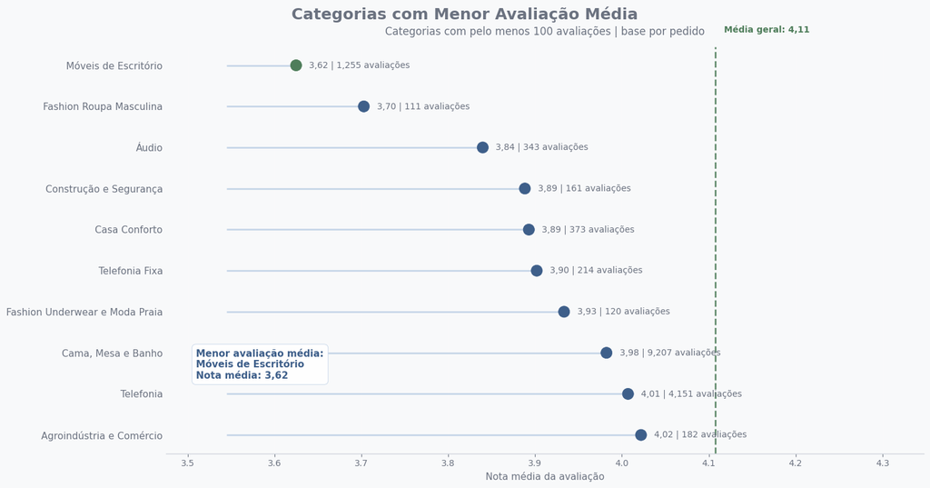

| categoria | nota_media | qtd_avaliacoes |
| --- | --- | --- |
| Móveis de Escritório | 3.620000 | 1255 |
| Fashion Roupa Masculina | 3.700000 | 111 |
| Áudio | 3.840000 | 343 |
| Construção e Segurança | 3.890000 | 161 |
| Casa Conforto | 3.890000 | 373 |
| Telefonia Fixa | 3.900000 | 214 |
| Fashion Underwear e Moda Praia | 3.930000 | 120 |
| Cama, Mesa e Banho | 3.980000 | 9207 |
| Telefonia | 4.010000 | 4151 |
| Agroindústria e Comércio | 4.020000 | 182 |

### Principais Resultados Gráfico 7.3

- As categorias analisadas apresentaram notas médias entre **3,62 e 4,02**, todas abaixo da média geral da plataforma (**4,11**).
- **Móveis de Escritório** apresentou a menor avaliação média (**3,62**) entre as categorias com pelo menos 100 avaliações.
- Categorias como **Fashion Roupa Masculina**, **Áudio** e **Construção e Segurança** também apresentaram níveis de satisfação inferiores à média geral.
- Algumas categorias com elevado volume de avaliações, como **Cama, Mesa e Banho** e **Telefonia**, apresentaram notas abaixo da média da plataforma, indicando oportunidades de melhoria em segmentos relevantes para o negócio.
- As diferenças observadas sugerem que a experiência dos clientes não é uniforme entre os diferentes segmentos de produtos.

### Insight Executivo

A satisfação dos clientes varia entre categorias, indicando que determinados segmentos enfrentam desafios específicos relacionados à experiência de compra. Embora a média geral da plataforma seja elevada, algumas categorias apresentam avaliações consistentemente inferiores, o que pode representar riscos reputacionais e oportunidades de melhoria operacional.

### Recomendação

Monitorar continuamente as categorias com menor satisfação e aprofundar a investigação dos fatores associados às avaliações recebidas. A análise dos drivers de satisfação permitirá identificar se aspectos como prazo de entrega, pontualidade, frete ou valor das compras estão relacionados às diferenças observadas entre categorias.

**Problema de Negócio**

**Objetivo**

**Hipótese**

**Decisão Apoiada**

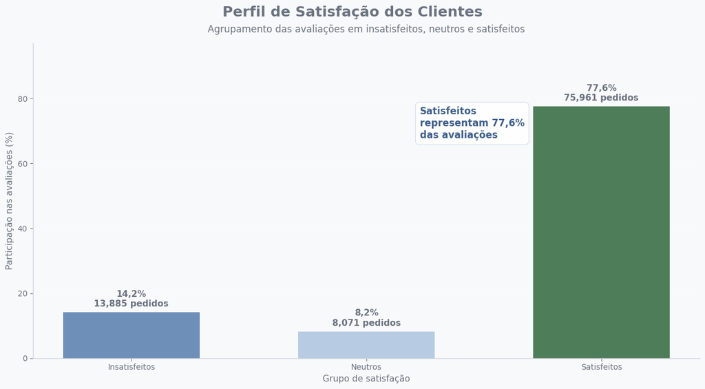

| grupo_satisfacao | pedidos | participacao |
| --- | --- | --- |
| Insatisfeitos | 13885 | 14.200000 |
| Neutros | 8071 | 8.200000 |
| Satisfeitos | 75961 | 77.600000 |

### Principais Resultados Gráfico 7.4

- A maior parte das avaliações está concentrada no grupo de **clientes satisfeitos**, formado por notas 4 e 5.
- O grupo de **clientes insatisfeitos**, composto por notas 1 e 2, representa a parcela de maior atenção para a gestão da experiência.
- As avaliações neutras, representadas pela nota 3, indicam clientes com percepção intermediária da experiência de compra.
- A segmentação por grupos facilita a leitura executiva da satisfação em comparação à análise isolada das notas de 1 a 5.

### Insight Executivo

O agrupamento das avaliações mostra que a plataforma possui uma base relevante de clientes satisfeitos, mas também evidencia a existência de um grupo de clientes em risco. Essa leitura é importante porque transforma as notas individuais em grupos de decisão, permitindo compreender melhor o tamanho da satisfação e da insatisfação dentro da base.

### Recomendação

Utilizar o perfil de satisfação como indicador executivo de acompanhamento da experiência do cliente. A partir dessa visão, a próxima etapa deve investigar os fatores associados à insatisfação, especialmente prazo de entrega, pontualidade, frete e valor do pedido.

### 7.5 - Evolução Mensal da Avaliação Média

**Problema de Negócio**

Investidores precisam compreender se a satisfação dos clientes evoluiu positivamente ao longo do crescimento da plataforma ou se a expansão comercial ocorreu acompanhada de deterioração da experiência dos clientes.

**Objetivo**

Analisar a evolução mensal da nota média atribuída pelos clientes, identificando tendências de melhoria, estabilidade ou deterioração da satisfação ao longo do período analisado.

**Hipótese**

A satisfação dos clientes permaneceu estável ou apresentou leve melhoria ao longo do período, mesmo diante do forte crescimento da plataforma.

**Decisão Apoiada**

Avaliar a capacidade da Olist de sustentar crescimento comercial sem comprometer a experiência dos clientes.

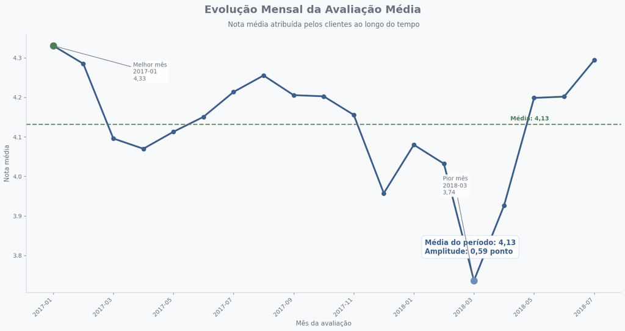

| ano_mes | nota_media | pedidos |
| --- | --- | --- |
| 2017-01 | 4.330000 | 236 |
| 2017-02 | 4.280000 | 1400 |
| 2017-03 | 4.100000 | 2402 |
| 2017-04 | 4.070000 | 2021 |
| 2017-05 | 4.110000 | 3665 |
| 2017-06 | 4.150000 | 3362 |
| 2017-07 | 4.210000 | 3435 |
| 2017-08 | 4.260000 | 4412 |
| 2017-09 | 4.210000 | 4124 |
| 2017-10 | 4.200000 | 4361 |
| 2017-11 | 4.160000 | 4675 |
| 2017-12 | 3.960000 | 7846 |
| 2018-01 | 4.080000 | 6113 |
| 2018-02 | 4.030000 | 6005 |
| 2018-03 | 3.740000 | 7669 |
| 2018-04 | 3.930000 | 7260 |
| 2018-05 | 4.200000 | 7435 |
| 2018-06 | 4.200000 | 6694 |
| 2018-07 | 4.290000 | 5595 |

### Principais Resultados Gráfico 7.5

- A avaliação média dos clientes permaneceu relativamente estável ao longo do período analisado.
- A satisfação oscilou entre **3,74 e 4,33**, mantendo-se próxima da média geral de **4,13**.
- O melhor resultado ocorreu em **jan/2017**, com nota média de **4,33**.
- O menor resultado foi observado em **mar/2018**, com nota média de **3,74**.
- Mesmo durante o forte crescimento operacional da plataforma, a satisfação dos clientes permaneceu em níveis elevados.

### Insight Executivo

Os resultados indicam que a Olist conseguiu sustentar níveis elevados de satisfação mesmo diante do crescimento expressivo da operação. A estabilidade observada ao longo do período sugere que a expansão da plataforma não comprometeu significativamente a experiência percebida pelos clientes, fator relevante para a sustentabilidade do crescimento no longo prazo.

### Recomendação

Monitorar continuamente a evolução da satisfação dos clientes em conjunto com indicadores de crescimento, logística e desempenho operacional. A manutenção de avaliações médias superiores a 4 pontos representa uma vantagem competitiva importante para a retenção de clientes e para a atratividade do marketplace perante investidores.

# Conclusão da Seção 7 — Satisfação dos Clientes

A análise da satisfação dos clientes revelou uma predominância de avaliações positivas ao longo de todo o período analisado, com concentração significativa nas notas mais elevadas.

As diferenças observadas entre estados e categorias indicam que a percepção da experiência de compra não é homogênea, existindo oportunidades de melhoria específicas em determinados segmentos e regiões.

Além disso, a evolução temporal das avaliações demonstrou que a satisfação permaneceu relativamente estável mesmo diante do forte crescimento da plataforma, sugerindo que a expansão operacional não comprometeu significativamente a experiência dos clientes.

De forma geral, os resultados indicam que a Olist conseguiu combinar crescimento comercial com manutenção de níveis elevados de satisfação, criando uma base favorável para a investigação dos fatores que efetivamente influenciam as avaliações dos consumidores.

A próxima etapa busca identificar os principais drivers da satisfação dos clientes, avaliando o impacto de fatores logísticos, financeiros e operacionais sobre as avaliações atribuídas.

## 8 - Análise Diagnóstica dos Drivers de Satisfação

Após compreender o comportamento da satisfação dos clientes e os principais indicadores da experiência de compra, a próxima etapa consiste em investigar quais fatores estão mais associados às avaliações atribuídas pelos consumidores.

Enquanto as análises anteriores tiveram caráter predominantemente descritivo, esta seção possui natureza diagnóstica e busca identificar padrões, relações e evidências que auxiliem na compreensão dos principais fatores que influenciam a satisfação dos clientes.

O objetivo é transformar observações descritivas em conhecimento acionável, permitindo identificar quais aspectos da operação possuem maior potencial de impactar positivamente a experiência dos consumidores.

As análises desta seção servirão como base para a construção das recomendações estratégicas apresentadas ao final do projeto.

### 8.1 - Matriz de Correlação dos Drivers de Satisfação

**Problema de Negócio**

Embora diversas análises tenham indicado possíveis relações entre logística, valor do pedido e satisfação dos clientes, ainda é necessário avaliar de forma integrada quais variáveis apresentam maior associação com as avaliações atribuídas pelos consumidores.

**Objetivo**

Analisar a correlação entre os principais drivers da experiência de compra e a nota de avaliação dos clientes, identificando quais fatores apresentam maior potencial de influência sobre a satisfação.

**Hipótese**

Variáveis relacionadas à logística, especialmente atraso e tempo de entrega, apresentam maior associação com a satisfação dos clientes do que fatores financeiros, como preço dos produtos ou valor do frete.

**Decisão Apoiada**

Identificar quais fatores merecem maior atenção estratégica para melhoria da experiência dos clientes e priorização de investimentos operacionais.

| variável | Avaliação | Tempo de Entrega | Atraso | Valor do Pedido | Frete |
| --- | --- | --- | --- | --- | --- |
| Avaliação | 1.000000 | -0.330000 | -0.270000 | -0.010000 | -0.040000 |
| Tempo de Entrega | -0.330000 | 1.000000 | 0.600000 | 0.060000 | 0.210000 |
| Atraso | -0.270000 | 0.600000 | 1.000000 | -0.010000 | -0.050000 |
| Valor do Pedido | -0.010000 | 0.060000 | -0.010000 | 1.000000 | 0.420000 |
| Frete | -0.040000 | 0.210000 | -0.050000 | 0.420000 | 1.000000 |

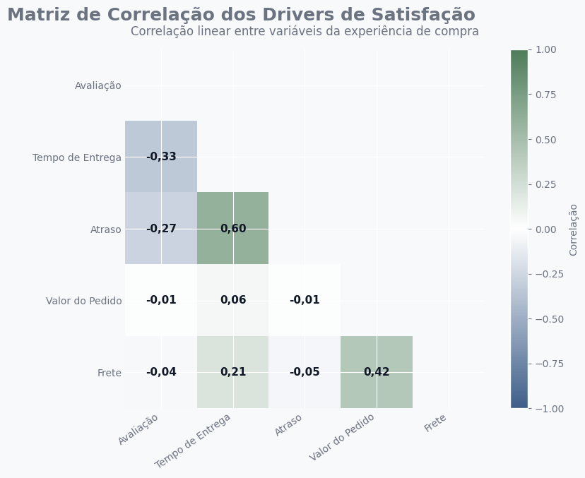

| driver | correlacao |
| --- | --- |
| Tempo de Entrega | -0.330000 |
| Atraso | -0.270000 |
| Frete | -0.040000 |
| Valor do Pedido | -0.010000 |

### Principais Resultados Gráfico 8.1

- O **tempo de entrega apresentou a maior correlação com a satisfação dos clientes**, com coeficiente de **-0,33**.
- O **atraso na entrega apresentou a segunda maior correlação**, com coeficiente de **-0,27**.
- O **valor do pedido apresentou correlação praticamente nula com a satisfação**, com coeficiente de **-0,01**.
- O **valor do frete também apresentou baixa associação com a avaliação dos clientes**, com correlação de **-0,04**.
- Foi observada correlação positiva de **0,60** entre tempo de entrega e atraso, indicando forte relação entre demora operacional e descumprimento do prazo prometido.

### Insight Executivo

Os resultados indicam que a satisfação dos clientes está significativamente mais associada à experiência logística do que aos fatores financeiros da compra. Tempo de entrega e atraso foram os fatores com maior relação com as avaliações, enquanto preço e frete demonstraram influência muito limitada na percepção dos consumidores.

### Recomendação

Priorizar iniciativas voltadas à redução do tempo de entrega e ao cumprimento dos prazos prometidos. Os resultados sugerem que melhorias logísticas possuem maior potencial de elevar a satisfação dos clientes do que ações focadas exclusivamente em preço ou frete.

### 8.2 - Ranking dos Drivers de Satisfação

**Problema de Negócio**

Após identificar as correlações entre os principais fatores da experiência de compra e a satisfação dos clientes, é necessário transformar esses resultados em uma priorização executiva clara.

**Objetivo**

Construir um ranking dos drivers de satisfação com base na intensidade da correlação com a nota de avaliação, destacando os fatores com maior associação à experiência do cliente.

**Hipótese**

Os fatores logísticos, especialmente tempo de entrega e atraso, ocupam as primeiras posições no ranking de drivers de satisfação.

**Decisão Apoiada**

Priorizar os fatores que devem receber maior atenção estratégica para melhoria da experiência do cliente e aumento da satisfação.

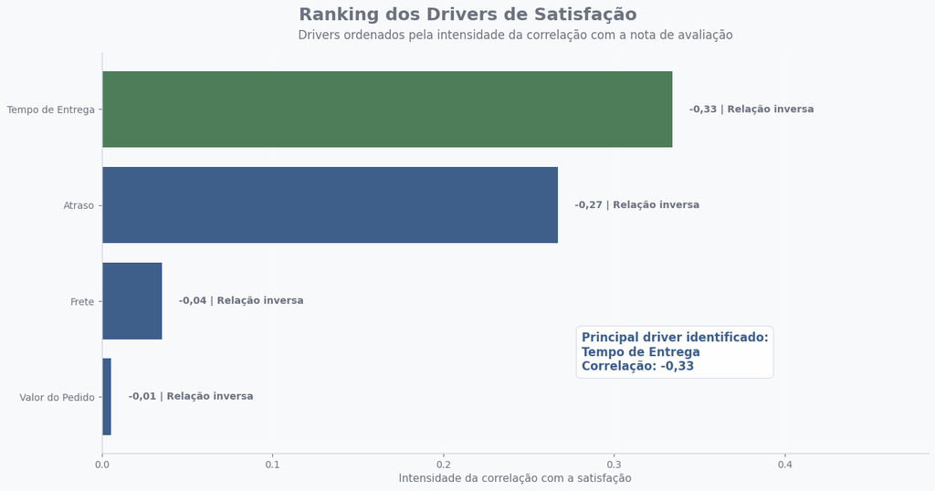

| driver | correlacao | intensidade | direcao |
| --- | --- | --- | --- |
| Tempo de Entrega | -0.330000 | 0.330000 | Relação inversa |
| Atraso | -0.270000 | 0.270000 | Relação inversa |
| Frete | -0.040000 | 0.040000 | Relação inversa |
| Valor do Pedido | -0.010000 | 0.010000 | Relação inversa |

### Principais Resultados Gráfico 8.2

- O **tempo de entrega foi identificado como o principal driver de satisfação**, apresentando correlação de **-0,33** com a nota de avaliação.
- O **atraso na entrega ocupou a segunda posição**, com correlação de **-0,27**.
- O **valor do frete apresentou baixa associação com a satisfação**, com coeficiente de **-0,04**.
- O **valor do pedido demonstrou influência praticamente nula sobre a avaliação dos clientes**, com correlação de **-0,01**.
- Os dois fatores logísticos apresentaram intensidade de correlação significativamente superior aos fatores financeiros analisados.

### Insight Executivo

Os resultados reforçam que a percepção dos clientes está fortemente associada à qualidade da execução logística. O tempo necessário para receber o pedido e o cumprimento dos prazos prometidos exercem influência muito superior ao valor pago pelo produto ou pelo frete, indicando que a experiência operacional é o principal fator de satisfação na plataforma.

### Recomendação

Priorizar investimentos em eficiência logística, redução do tempo de entrega e melhoria da previsibilidade dos prazos. Essas iniciativas possuem maior potencial de elevar a satisfação dos clientes do que ações focadas exclusivamente em preço ou frete.

### 8.3 - Comparação dos Drivers entre Clientes Satisfeitos e Insatisfeitos

**Problema de Negócio**

Embora as correlações indiquem quais fatores estão associados à satisfação, é importante compreender como esses drivers se comportam na prática entre clientes satisfeitos e insatisfeitos.

**Objetivo**

Comparar os principais indicadores operacionais e financeiros entre diferentes grupos de satisfação, identificando diferenças que possam explicar as avaliações atribuídas pelos clientes.

**Hipótese**

Clientes satisfeitos apresentam menor tempo de entrega e menor atraso médio quando comparados aos clientes insatisfeitos, enquanto preço e frete apresentam diferenças menos relevantes.

**Decisão Apoiada**

Identificar quais fatores operacionais devem ser priorizados para aumentar a satisfação dos clientes e reduzir avaliações negativas.

| grupo_satisfacao | tempo_entrega | atraso | valor_pedido | frete | pedidos |
| --- | --- | --- | --- | --- | --- |
| Insatisfeitos (1-2) | 19.750000 | -5.130000 | 132.100000 | 21.500000 | 12270 |
| Neutros (3) | 13.790000 | -10.780000 | 113.960000 | 20.350000 | 7909 |
| Satisfeitos (4-5) | 10.620000 | -13.130000 | 125.110000 | 19.920000 | 75651 |

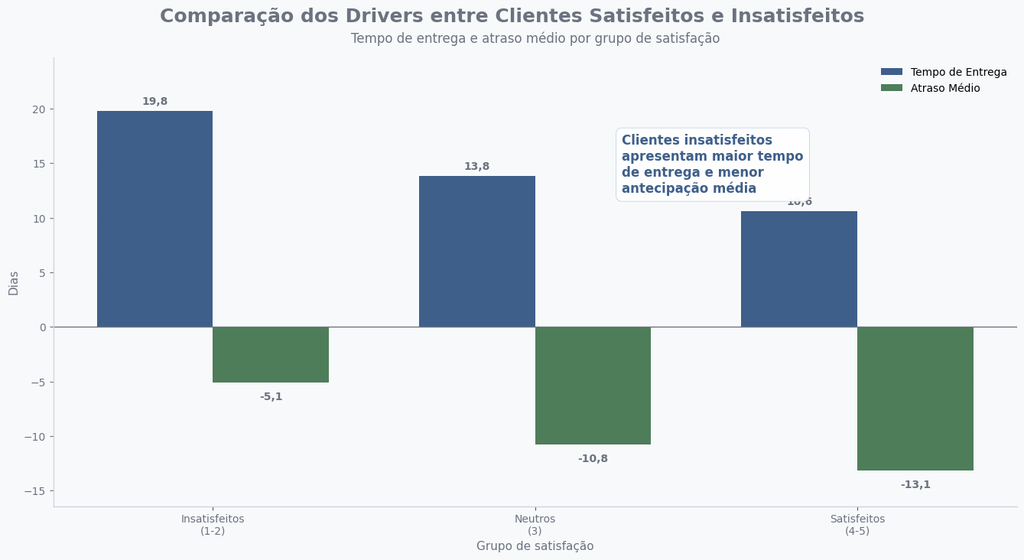

### Principais Resultados Gráfico 8.3

- Clientes insatisfeitos apresentaram tempo médio de entrega de **19,8 dias**, enquanto clientes satisfeitos receberam seus pedidos em média após **10,6 dias**.
- Clientes satisfeitos receberam seus pedidos, em média, **13,1 dias antes do prazo previsto**, enquanto clientes insatisfeitos receberam apenas **5,1 dias antes do prazo**.
- Observou-se uma redução consistente no tempo de entrega conforme aumenta o nível de satisfação dos clientes.
- A antecipação das entregas também aumenta progressivamente entre os grupos de satisfação mais elevados.
- Os resultados reforçam os achados das análises de correlação e ranking dos drivers de satisfação.

### Insight Executivo

A experiência logística apresenta impacto direto na percepção dos clientes. Consumidores satisfeitos não apenas recebem seus pedidos mais rapidamente, mas também experimentam maior antecipação em relação ao prazo prometido. A diferença observada entre os grupos sugere que a eficiência logística é um dos principais fatores associados à satisfação na plataforma.

### Recomendação

Priorizar iniciativas de redução do tempo de entrega e aumento da previsibilidade operacional. Os resultados indicam que melhorias logísticas possuem elevado potencial para aumentar a satisfação dos clientes e reduzir avaliações negativas.

### 8.4 - Prazo Médio de Entrega por Avaliação

**Problema de Negócio**

Investidores precisam entender se o tempo de entrega influencia a satisfação dos clientes.

**Objetivo**

Comparar o prazo médio de entrega entre as diferentes notas de avaliação.

**Hipótese**

Pedidos com menor tempo de entrega tendem a receber avaliações mais altas.

**Decisão Apoiada**

Priorizar melhorias logísticas como alavanca de satisfação e retenção dos clientes.

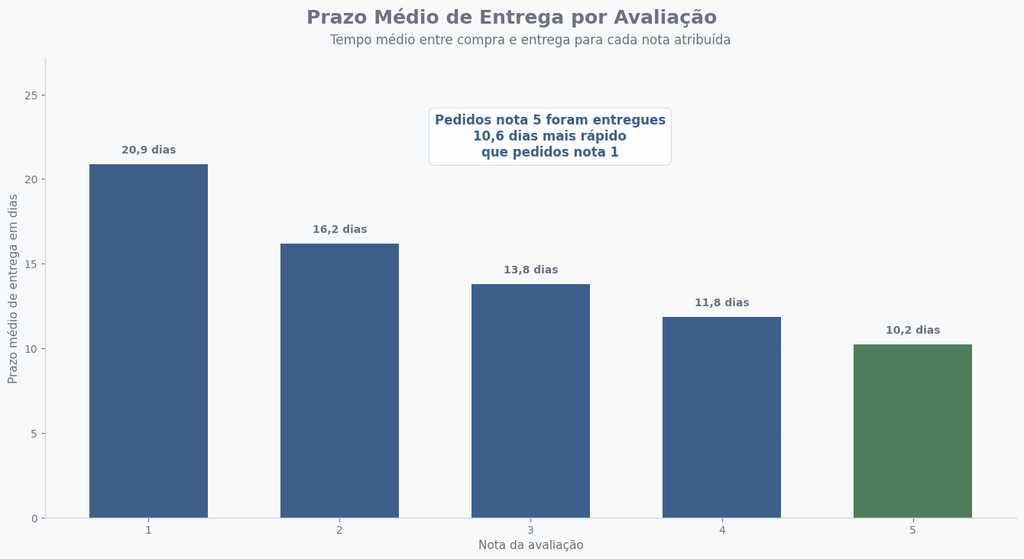

| nota | prazo_medio_dias | pedidos_avaliados |
| --- | --- | --- |
| 1 | 20.860000 | 9347 |
| 2 | 16.200000 | 2923 |
| 3 | 13.790000 | 7909 |
| 4 | 11.840000 | 18893 |
| 5 | 10.220000 | 56758 |

### Principais Resultados Gráfico 8.4

- As avaliações mais baixas apresentaram **maior prazo médio de entrega**.
- Pedidos com nota 5 tiveram **menor tempo médio de entrega**.
- A diferença entre os extremos evidencia relação relevante entre logística e satisfação.

### Insight Executivo

O prazo de entrega aparece como um dos principais fatores associados à experiência do cliente. Quanto menor o tempo até a entrega, maior tende a ser a avaliação recebida.

### Recomendação

Priorizar ações de redução do prazo médio de entrega, especialmente em rotas e categorias com maior concentração de avaliações baixas.

### 8.5 - Entregas Antes do Prazo por Avaliação

**Problema de Negócio**

Entregar rapidamente é importante, mas cumprir ou antecipar o prazo prometido pode ser ainda mais relevante para a percepção dos clientes.

**Objetivo**

Analisar a antecedência média da entrega em relação à data prometida para cada nota de avaliação, verificando se clientes mais satisfeitos receberam seus pedidos com maior antecedência.

**Hipótese**

Clientes que receberam seus pedidos antes da data prometida tendem a atribuir avaliações mais altas.

**Decisão Apoiada**

Avaliar o impacto do cumprimento e da antecipação dos prazos na experiência do cliente e orientar melhorias operacionais.

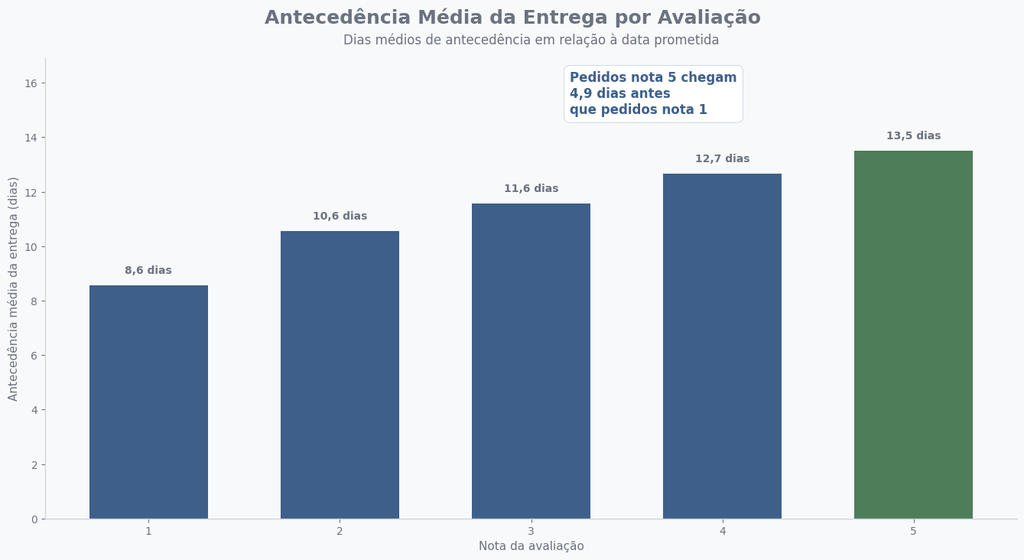

| nota | antecedencia_media_dias | pedidos_avaliados |
| --- | --- | --- |
| 1 | 8.570000 | 9347 |
| 2 | 10.560000 | 2923 |
| 3 | 11.570000 | 7909 |
| 4 | 12.670000 | 18893 |
| 5 | 13.510000 | 56758 |

### Principais Resultados Gráfico 8.5

- Observou-se uma associação positiva entre a antecedência da entrega e a satisfação dos clientes.
- Pedidos avaliados com nota **1** foram entregues, em média, **8,6 dias antes** da data prometida.
- Pedidos avaliados com nota **5** foram entregues, em média, **13,5 dias antes** da data prometida.
- A diferença entre os extremos foi de aproximadamente **4,9 dias de antecedência**.
- Verificou-se uma evolução consistente da antecedência média conforme aumenta a nota atribuída pelos clientes.

### Insight Executivo

Os resultados indicam que a satisfação dos clientes está associada não apenas ao prazo absoluto de entrega, mas também à capacidade da operação em superar a expectativa criada no momento da compra. Clientes que recebem seus pedidos com maior antecedência em relação ao prazo prometido tendem a atribuir avaliações mais elevadas à experiência de compra.

### Recomendação

Manter iniciativas voltadas à previsibilidade logística e à entrega antecipada sempre que operacionalmente viável. Além da redução do tempo médio de entrega, a capacidade de superar as expectativas dos clientes em relação ao prazo prometido pode contribuir para o aumento da satisfação e para o fortalecimento da reputação da plataforma.

### 8.6 - Impacto da Pontualidade na Satisfação dos Clientes

## Problema de Negócio

Atrasos na entrega afetam a satisfação dos clientes da Olist?

## Objetivo

Analisar como diferentes níveis de atraso ou antecipação na entrega influenciam as avaliações atribuídas pelos clientes, identificando o impacto da pontualidade logística na experiência de compra.

## Hipótese

Pedidos entregues dentro ou antes do prazo tendem a receber avaliações mais altas, enquanto atrasos prolongados reduzem significativamente a satisfação dos clientes.

## Decisão Apoiada

Avaliar a relevância da eficiência logística como fator determinante da satisfação dos clientes, apoiando decisões relacionadas à gestão de transportadoras, prazos de entrega e investimentos operacionais.

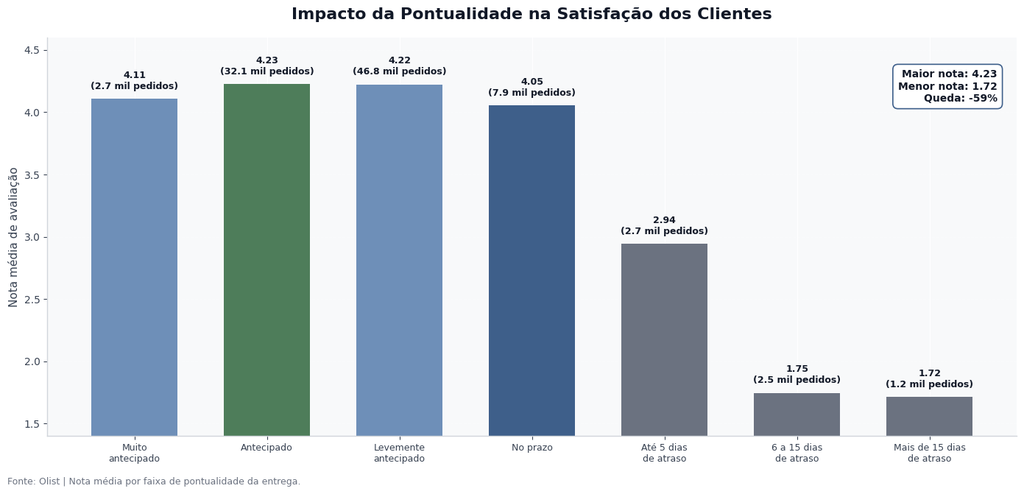

### Principais Resultados Gráfico 8.6

- Observou-se uma diferença significativa na satisfação dos clientes entre pedidos entregues dentro do prazo e pedidos entregues com atraso.
- Clientes que receberam seus pedidos dentro ou antes do prazo apresentaram avaliações médias superiores às observadas em pedidos entregues após a data prometida.
- O atraso na entrega mostrou associação negativa com a satisfação, indicando redução das avaliações à medida que aumenta o descumprimento do prazo prometido.
- Os resultados reforçam a relevância da pontualidade como um dos principais fatores associados à percepção da experiência de compra.
- A análise confirma os achados observados anteriormente nas análises de correlação, antecedência de entrega e comparação entre grupos de satisfação.

### Insight Executivo

Os resultados demonstram que o cumprimento do prazo prometido constitui um dos fatores mais relevantes para a satisfação dos clientes. Mais do que a velocidade absoluta da entrega, a consistência entre a expectativa criada no momento da compra e a experiência efetivamente recebida influencia diretamente a percepção de qualidade do serviço. Clientes impactados por atrasos tendem a apresentar avaliações significativamente inferiores, mesmo quando o prazo total de entrega não é elevado.

### Recomendação

Priorizar iniciativas voltadas ao aumento da previsibilidade logística e à redução dos atrasos operacionais. O monitoramento contínuo dos indicadores de pontualidade deve ser tratado como prioridade estratégica, uma vez que o cumprimento dos prazos prometidos possui elevado potencial de impacto sobre a satisfação dos clientes e sobre a reputação da plataforma.

### 8.7 - Valor Médio do Pedido por Avaliação

**Problema de Negócio**

O valor da compra influencia a percepção dos clientes sobre a experiência de compra?

**Objetivo**

Analisar o valor médio dos pedidos para cada nota de avaliação, verificando se pedidos de maior valor estão associados a níveis diferentes de satisfação.

**Hipótese**

Pedidos de maior valor podem gerar expectativas mais elevadas dos clientes, influenciando as avaliações atribuídas.

**Decisão Apoiada**

Avaliar se o valor financeiro das compras representa um fator relevante para a satisfação dos clientes.

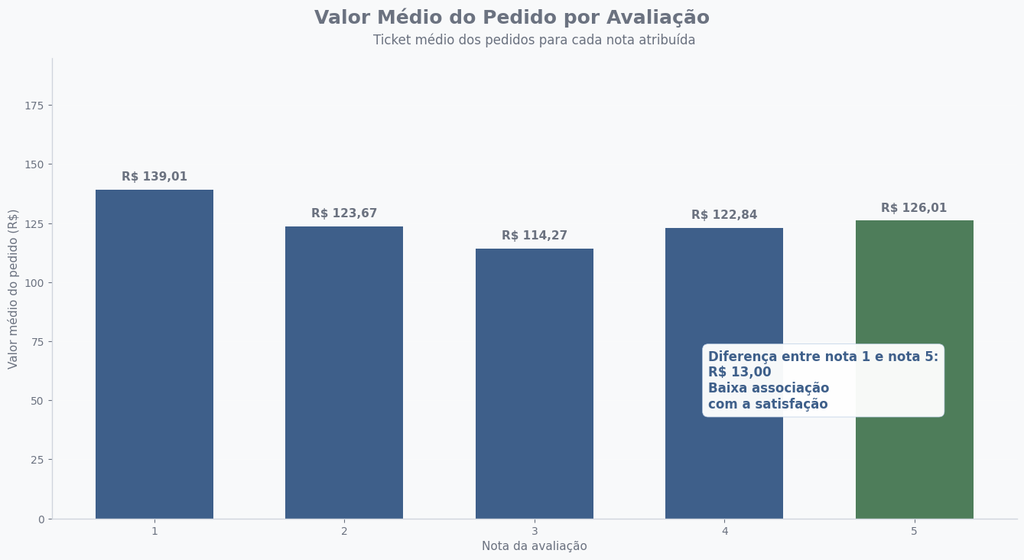

| review_score | ticket_medio | pedidos_avaliados |
| --- | --- | --- |
| 1 | 139.010000 | 10814 |
| 2 | 123.670000 | 3071 |
| 3 | 114.270000 | 8071 |
| 4 | 122.840000 | 19012 |
| 5 | 126.010000 | 56949 |

### Insight Executivo

O valor médio do pedido não parece explicar de forma relevante as diferenças de satisfação observadas entre os clientes. Embora pedidos com nota 1 apresentem ticket médio ligeiramente superior, a diferença é pequena frente aos fatores logísticos analisados anteriormente, como pontualidade, antecedência e tempo de entrega.

### Recomendação

Tratar o valor do pedido como fator complementar de análise, sem priorizá-lo como principal alavanca de satisfação. As evidências indicam que iniciativas voltadas à eficiência logística possuem maior potencial de impacto sobre a experiência do cliente do que ações focadas exclusivamente no valor da compra.

### 8.8 - Valor Médio do Frete por Avaliação

**Problema de Negócio**

O valor do frete influencia a percepção dos clientes sobre a experiência de compra?

**Objetivo**

Analisar o valor médio do frete para cada nota de avaliação, verificando se fretes mais elevados estão associados a menores níveis de satisfação.

**Hipótese**

Pedidos com fretes mais altos tendem a receber avaliações inferiores, indicando que o custo de entrega pode influenciar a percepção de valor da compra.

**Decisão Apoiada**

Avaliar o impacto do frete na satisfação dos clientes e identificar oportunidades para melhorar a competitividade da plataforma.

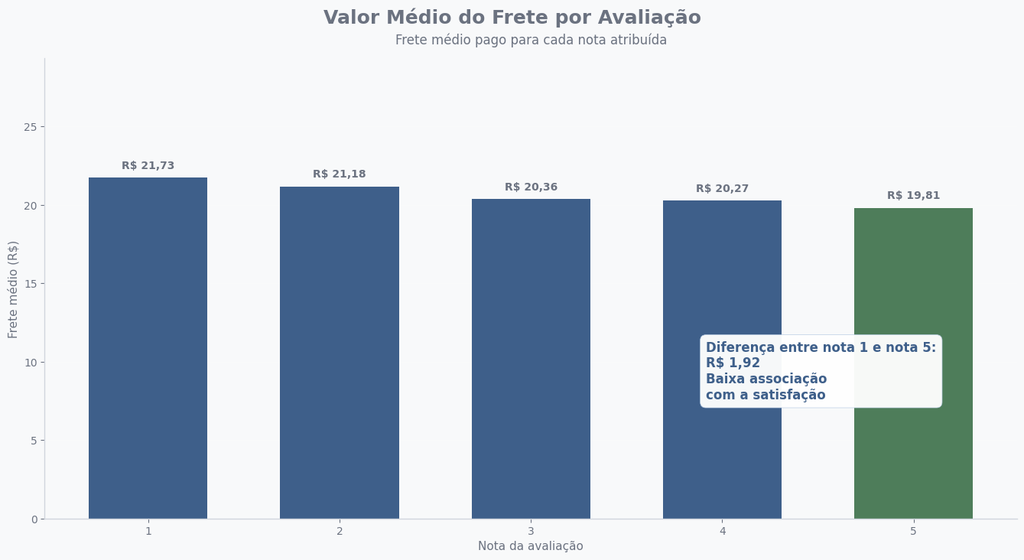

| review_score | frete_medio | pedidos_avaliados |
| --- | --- | --- |
| 1 | 21.730000 | 10814 |
| 2 | 21.180000 | 3071 |
| 3 | 20.360000 | 8071 |
| 4 | 20.270000 | 19012 |
| 5 | 19.810000 | 56949 |

### Insight Executivo

O valor médio do frete apresenta variação pequena entre os diferentes níveis de avaliação. Embora pedidos com nota 1 tenham frete ligeiramente superior aos pedidos com nota 5, essa diferença é limitada e não demonstra força explicativa comparável aos fatores logísticos, como pontualidade, tempo de entrega e antecedência.

### Recomendação

Monitorar o frete como fator complementar da experiência do cliente, especialmente em pedidos com avaliações negativas. Entretanto, priorizar as iniciativas voltadas à eficiência logística e ao cumprimento dos prazos, pois os resultados indicam maior potencial de impacto sobre a satisfação dos clientes.

### 8.9 - Matriz de Priorização dos Drivers de Satisfação

**Problema de Negócio**

Após identificar os principais fatores associados à satisfação dos clientes, é necessário determinar quais drivers devem receber maior atenção estratégica para maximizar o impacto das iniciativas de melhoria.

**Objetivo**

Priorizar os drivers de satisfação considerando simultaneamente sua associação com as avaliações dos clientes e as diferenças observadas entre clientes satisfeitos e insatisfeitos.

**Hipótese**

Os fatores logísticos apresentam maior potencial de impacto na satisfação dos clientes quando comparados aos fatores financeiros analisados.

**Decisão Apoiada**

Definir prioridades para investimentos operacionais e iniciativas de melhoria da experiência do cliente.

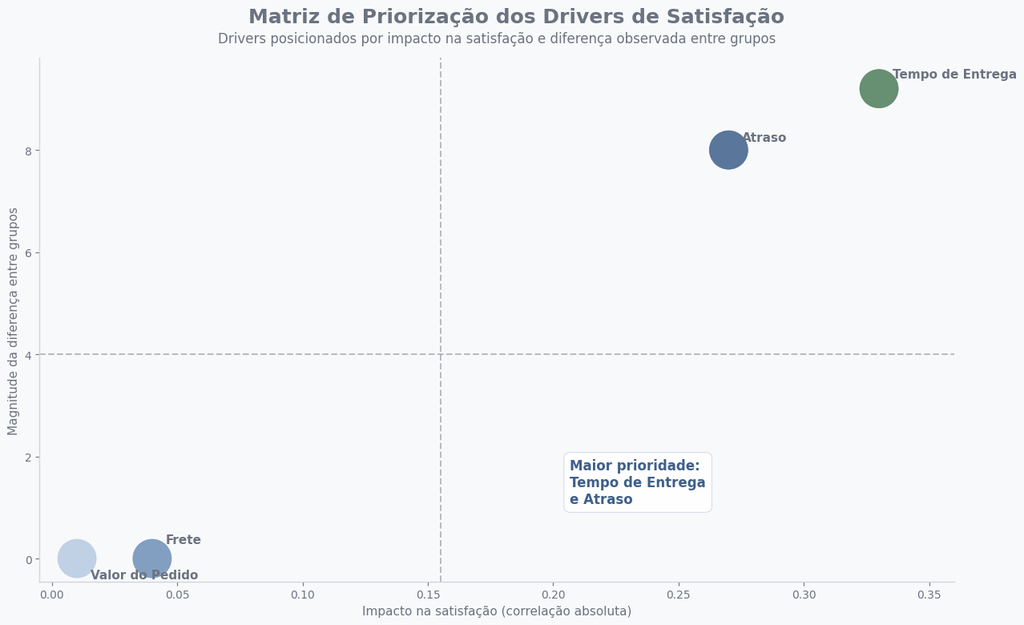

| driver | impacto | diferenca |
| --- | --- | --- |
| Tempo de Entrega | 0.330000 | 9.200000 |
| Atraso | 0.270000 | 8.000000 |
| Frete | 0.040000 | 0.000000 |
| Valor do Pedido | 0.010000 | 0.000000 |

### Insight Executivo

A satisfação dos clientes da Olist é predominantemente influenciada pela qualidade da experiência logística e não pelo valor financeiro da compra. O tempo de entrega e os atrasos possuem impacto significativamente superior ao frete ou ao valor dos pedidos, indicando que os clientes valorizam mais a eficiência operacional do que fatores monetários isolados.

### Recomendação

Direcionar investimentos prioritariamente para redução do tempo de entrega, melhoria da previsibilidade logística e controle de atrasos. Estratégias focadas exclusivamente em redução de frete ou alterações de preço tendem a gerar impacto consideravelmente menor na satisfação dos clientes quando comparadas aos ganhos obtidos por melhorias logísticas.

### 8.10 - Síntese Executiva dos Drivers de Satisfação

**Problema de Negócio**

Após analisar individualmente os principais fatores associados à satisfação, investidores precisam compreender quais drivers devem ser priorizados para melhorar a experiência dos clientes.

**Objetivo**

Consolidar os principais drivers de satisfação em uma visão executiva, comparando a força de associação de fatores logísticos e financeiros com as avaliações dos clientes.

**Hipótese**

Fatores logísticos, especialmente prazo de entrega e atraso, apresentam maior associação com a satisfação do cliente do que fatores financeiros, como valor do pedido e frete.

**Decisão Apoiada**

Priorizar iniciativas operacionais com maior potencial de impacto na satisfação dos clientes e na sustentabilidade do crescimento da plataforma. da plataforma.

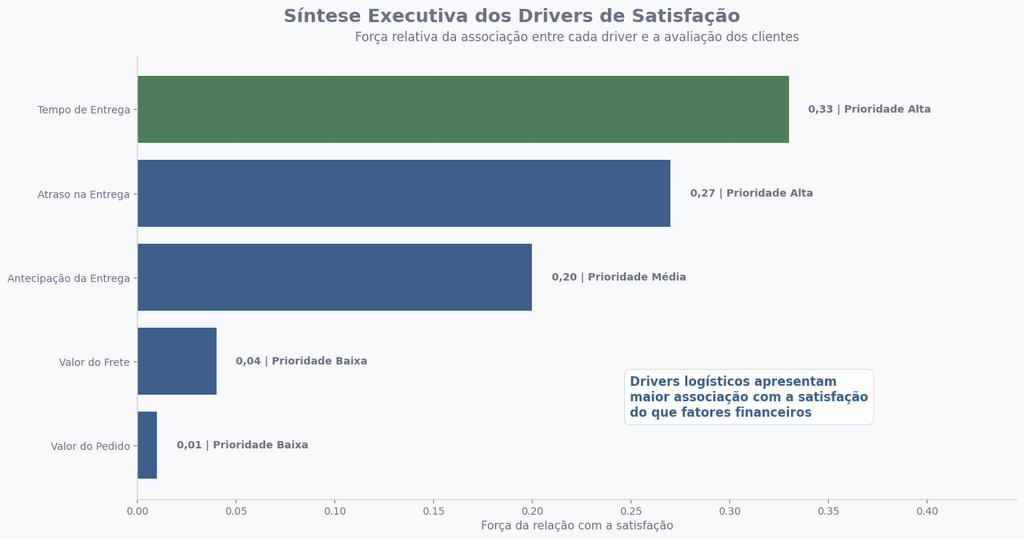

| driver | forca_relacao | prioridade |
| --- | --- | --- |
| Tempo de Entrega | 0.330000 | Alta |
| Atraso na Entrega | 0.270000 | Alta |
| Antecipação da Entrega | 0.200000 | Média |
| Valor do Frete | 0.040000 | Baixa |
| Valor do Pedido | 0.010000 | Baixa |

### Principais Resultados Gráfico 8.10

- O **tempo de entrega** aparece como o principal driver associado à satisfação dos clientes.
- O **atraso na entrega** é o segundo fator mais relevante na explicação das avaliações.
- A **antecipação da entrega** também apresenta relevância, reforçando o papel da previsibilidade logística.
- O **valor do frete** e o **valor do pedido** apresentam baixa associação com a satisfação.
- Os resultados indicam que os fatores logísticos possuem maior peso na experiência percebida pelos clientes do que os fatores financeiros.

### Insight Executivo

A satisfação dos clientes da Olist está mais fortemente associada à qualidade da experiência logística do que ao valor financeiro da compra. Isso indica que reduzir prazos, evitar atrasos e aumentar a previsibilidade da entrega são alavancas mais relevantes para melhorar a avaliação dos clientes do que atuar isoladamente sobre preço, frete ou ticket médio.

### Recomendação

Priorizar iniciativas de eficiência logística, com foco em redução do tempo de entrega, prevenção de atrasos e melhoria da previsibilidade dos prazos informados ao cliente. Essas ações tendem a gerar maior impacto na satisfação e fortalecer a percepção de confiabilidade da plataforma.

## Conclusão da Seção 8 — Drivers de Satisfação dos Clientes

A análise dos drivers de satisfação permitiu identificar os principais fatores associados às avaliações atribuídas pelos clientes da Olist.

Os resultados demonstraram que os fatores logísticos exercem influência significativamente maior sobre a satisfação do que fatores financeiros. De forma consistente ao longo das análises realizadas, clientes que receberam seus pedidos em menor prazo, com maior antecedência em relação à data prometida e sem atrasos apresentaram avaliações mais elevadas.

Por outro lado, o valor do frete e o valor do pedido apresentaram associações relativamente fracas com a satisfação, sugerindo que os clientes tendem a valorizar mais a qualidade da experiência de entrega do que aspectos puramente monetários da transação.

A análise também evidenciou que atrasos representam um dos principais riscos para a experiência do cliente, enquanto entregas antecipadas contribuem positivamente para a percepção de qualidade do serviço.

De forma geral, os resultados indicam que a eficiência logística constitui um dos principais diferenciais competitivos da plataforma, influenciando diretamente a satisfação dos consumidores e fortalecendo a experiência de compra.

### Principais Resultados da Seção 8

- O **tempo de entrega** apresentou a associação mais relevante com a satisfação dos clientes.
- O **atraso na entrega** foi identificado como um dos principais fatores associados às avaliações negativas.
- A **antecipação da entrega** demonstrou efeito positivo sobre a experiência dos consumidores.
- O **valor do frete** apresentou influência limitada sobre a satisfação.
- O **valor do pedido** mostrou baixa associação com as avaliações atribuídas.
- Os resultados indicam predominância dos fatores logísticos sobre os fatores financeiros na formação da percepção dos clientes.

### Insight Executivo

A satisfação dos clientes da Olist está fortemente relacionada à qualidade da experiência logística. O crescimento sustentável da plataforma depende não apenas da expansão comercial, mas também da capacidade de manter entregas rápidas, previsíveis e sem atrasos. A logística surge como um dos principais mecanismos de geração de valor para clientes e investidores.

### Recomendação

Priorizar investimentos em eficiência logística, com foco na redução dos tempos de entrega, prevenção de atrasos e aumento da previsibilidade operacional. As evidências indicam que melhorias nesses fatores possuem maior potencial de impacto na satisfação dos clientes do que iniciativas focadas exclusivamente em preço, frete ou ticket médio.

A partir dos resultados obtidos, a próxima etapa do relatório consiste na consolidação das conclusões gerais do projeto e na elaboração das recomendações estratégicas para investidores.

## 9 - Conclusões Estratégicas e Recomendações para Investidores

## Contexto da Análise

Após a avaliação do desempenho comercial, da eficiência logística, da satisfação dos clientes e dos principais drivers associados à experiência de compra, esta seção consolida os principais achados do estudo sob uma perspectiva executiva.

O objetivo é sintetizar as evidências identificadas ao longo das análises, traduzindo os resultados em recomendações estratégicas capazes de apoiar a tomada de decisão de investidores e demais stakeholders interessados na sustentabilidade e no potencial de crescimento da plataforma.

Diferentemente das seções anteriores, que tiveram foco na exploração e diagnóstico dos dados, esta etapa busca integrar os resultados obtidos e transformá-los em direcionamentos práticos para geração de valor, eficiência operacional e fortalecimento da experiência dos clientes.

As recomendações apresentadas foram construídas com base nas evidências observadas ao longo do estudo, considerando simultaneamente crescimento comercial, desempenho logístico e satisfação dos consumidores.

### 9.1 - Principais Descobertas do Estudo

### Crescimento Comercial

A Olist apresentou forte expansão operacional ao longo do período analisado. A receita cresceu aproximadamente 644%, enquanto o volume de pedidos aumentou cerca de 695%, evidenciando crescimento sustentado principalmente pelo ganho de escala da operação. O ticket médio permaneceu relativamente estável, indicando que a expansão foi impulsionada pelo aumento da base transacional e não por elevação relevante do valor médio das compras.

### Eficiência Logística

Os resultados demonstraram uma operação logística eficiente, com tempo médio de entrega próximo de 12 dias e predominância de entregas realizadas dentro ou antes do prazo prometido. Embora existam ocorrências de atraso, estas representam uma parcela minoritária das entregas realizadas pela plataforma.

### Satisfação dos Clientes

A satisfação dos clientes permaneceu elevada ao longo de todo o período analisado, com predominância de avaliações positivas e nota média superior a 4 pontos. Mesmo diante do forte crescimento operacional observado, não foram identificados sinais relevantes de deterioração da experiência dos consumidores.

### Drivers de Satisfação

A análise diagnóstica evidenciou que os fatores logísticos exercem influência significativamente maior sobre a satisfação dos clientes do que fatores financeiros. Tempo de entrega, atraso e antecipação da entrega apresentaram as associações mais relevantes com as avaliações recebidas, enquanto valor do frete e valor do pedido demonstraram impacto reduzido sobre a percepção dos consumidores.

### Principais Resultados da Seção 9.1

- A plataforma apresentou forte crescimento comercial ao longo do período analisado.
- O crescimento foi impulsionado principalmente pelo aumento do volume de pedidos.
- A operação logística demonstrou elevada eficiência e predominância de entregas dentro do prazo.
- A satisfação dos clientes permaneceu elevada mesmo durante a expansão da operação.
- Os fatores logísticos apresentaram maior influência sobre a satisfação do que fatores financeiros.
- Tempo de entrega e atraso foram identificados como os principais drivers da experiência dos clientes.

### Insight Executivo

Os resultados demonstram que a Olist conseguiu combinar crescimento acelerado, eficiência operacional e elevados níveis de satisfação dos clientes. Essa combinação representa um importante diferencial competitivo e fortalece a sustentabilidade do crescimento observado.

### Recomendação

Utilizar os resultados consolidados como base para priorização estratégica de investimentos, direcionando esforços principalmente para iniciativas relacionadas à eficiência logística, previsibilidade das entregas e manutenção da qualidade da experiência dos clientes.

## 9.2 - Recomendações Estratégicas para Investidores

Com base nos resultados obtidos ao longo das análises realizadas, foram identificadas oportunidades estratégicas capazes de contribuir para o crescimento sustentável da plataforma, melhoria da experiência dos clientes e fortalecimento da geração de valor no longo prazo.

### Recomendação 1 — Priorizar Investimentos em Eficiência Logística

A logística foi identificada como o principal fator associado à satisfação dos clientes. Reduções no tempo médio de entrega e melhorias na previsibilidade operacional tendem a gerar impacto direto na experiência dos consumidores.

Dessa forma, recomenda-se priorizar iniciativas voltadas à otimização da cadeia logística, ampliação da cobertura operacional e melhoria dos processos de entrega.

### Recomendação 2 — Reduzir Ocorrências de Atraso

Os atrasos apresentaram associação consistente com avaliações negativas e menor satisfação dos clientes.

Investimentos em monitoramento preventivo, identificação antecipada de riscos operacionais e gestão proativa de exceções podem contribuir para redução de impactos na experiência de compra.

### Recomendação 3 — Expandir Parcerias com Sellers de Melhor Desempenho

A análise comercial identificou vendedores com desempenho superior em geração de receita e eficiência operacional.

Estratégias de retenção, incentivo e expansão desses parceiros podem acelerar o crescimento da plataforma preservando padrões elevados de qualidade e satisfação dos clientes.

### Recomendação 4 — Sustentar Crescimento sem Comprometer a Experiência do Cliente

Os resultados demonstraram que a Olist conseguiu crescer mantendo níveis elevados de satisfação.

A continuidade desse desempenho depende da capacidade de equilibrar expansão comercial, eficiência operacional e qualidade da experiência oferecida aos consumidores.

Portanto, indicadores de satisfação devem permanecer integrados aos processos de tomada de decisão e acompanhamento da performance da plataforma.

### Recomendação 5 — Utilizar Métricas de Satisfação como Indicadores Estratégicos

Tempo de entrega, atraso, antecipação da entrega e avaliações dos clientes devem ser acompanhados continuamente como indicadores estratégicos do negócio.

O monitoramento sistemático desses fatores pode permitir identificação precoce de riscos operacionais e apoiar decisões mais assertivas relacionadas à expansão da operação.

### Principais Recomendações Prioritárias

| Prioridade | Recomendação | Impacto Esperado |
| --- | --- | --- |
| Alta | Redução do tempo de entrega | Aumento da satisfação |
| Alta | Redução dos atrasos | Redução de avaliações negativas |
| Alta | Expansão de sellers de alta performance | Crescimento sustentável |
| Média | Ampliação da previsibilidade logística | Melhoria da experiência |
| Média | Monitoramento contínuo da satisfação | Gestão preventiva |

### Insight Executivo

Os resultados indicam que o crescimento sustentável da plataforma está diretamente associado à capacidade de manter elevados padrões de eficiência logística e qualidade da experiência dos clientes. A logística emerge como a principal alavanca de geração de valor identificada neste estudo.

### Recomendação

Priorizar investimentos em eficiência operacional e logística, direcionando recursos para iniciativas com maior potencial de impacto na satisfação dos clientes e na sustentabilidade do crescimento da plataforma.

## 9.3 - Considerações Finais para Investidores

Este estudo teve como objetivo analisar os fatores da experiência de compra que influenciam a satisfação dos clientes da Olist, transformando dados operacionais e transacionais em informações relevantes para apoio à tomada de decisão.

Os resultados demonstraram que a plataforma apresentou crescimento expressivo ao longo do período analisado, sustentado principalmente pela expansão do volume de pedidos e pela ampliação da atividade comercial.

Paralelamente ao crescimento observado, a Olist manteve níveis elevados de satisfação dos clientes, evidenciando capacidade operacional para absorver o aumento da demanda sem comprometer significativamente a qualidade da experiência de compra.

A análise dos drivers de satisfação permitiu identificar que os fatores logísticos representam os principais determinantes da percepção dos consumidores. Tempo de entrega, atraso e antecipação da entrega apresentaram influência significativamente superior aos fatores financeiros avaliados, reforçando a importância estratégica da eficiência operacional para a geração de valor.

Sob a perspectiva de investimento, os resultados sugerem a existência de fundamentos operacionais consistentes, combinando crescimento, satisfação dos clientes e eficiência logística. Esses fatores contribuem para a construção de vantagens competitivas sustentáveis e fortalecem a capacidade da plataforma de gerar valor no longo prazo.

Por fim, as evidências obtidas ao longo deste estudo indicam que a manutenção da excelência logística, associada à expansão sustentável da operação, representa uma das principais oportunidades para continuidade do crescimento e fortalecimento da competitividade da Olist no mercado de comércio eletrônico brasileiro.

### Mensagem Final

Os resultados deste estudo demonstram que crescimento sustentável, eficiência logística e satisfação dos clientes não são objetivos conflitantes. No caso da Olist, as evidências indicam que esses fatores atuam de forma complementar, reforçando a importância da experiência do cliente como elemento estratégico para geração de valor e sustentação do crescimento no longo prazo.

# Encerramento

Este relatório analisou dados transacionais da Olist com o objetivo de compreender o desempenho comercial da plataforma, sua eficiência logística e os fatores associados à satisfação dos clientes.

A partir da integração entre análises descritivas e diagnósticas, foi possível identificar padrões relevantes de crescimento, eficiência operacional e comportamento dos consumidores, transformando dados históricos em evidências capazes de apoiar decisões estratégicas.

Os resultados obtidos reforçam a importância da logística como principal alavanca de satisfação dos clientes e destacam a capacidade da plataforma de combinar expansão comercial com manutenção da qualidade da experiência oferecida aos consumidores.

Dessa forma, conclui-se que a Olist apresenta características compatíveis com uma operação escalável, orientada à experiência do cliente e com potencial para sustentar crescimento no longo prazo.

**Tech Challenge – FIAP | Data Analytics**

**Grupo 12**

**Brazilian E-Commerce Public Dataset by Olist**

## A

**Análise Diagnóstica**: Responde: *Por que aconteceu?* Exemplos:

- *Relação entre atraso e nota*
- *Relação entre frete e satisfação*
- *Comparação entre estados para entender diferenças*
- *Categorias que geram mais reclamações*  
  **Investiga as possíveis causas e fatores que explicam os resultados observados nos dados.**

**Análise Preditiva**:Responde: Pergunta: *O que devemos fazer? ou Qual ação devemos tomar para alcançar um resultado melhor?* Exemplos:

- O que devemos fazer para aumentar a satisfação dos clientes?
- O que devemos fazer para reduzir atrasos?
- O que devemos fazer para aumentar as vendas?

**Recomenda ações para melhorar resultados ou resolver problemas identificados na análise.**

**Append:** Significa Adicionar ao final. Método utilizado em listas para adicionar um novo elemento ao final da estrutura. É frequentemente utilizado para armazenar resultados gerados durante loops e análises de dados.

**Atributos**: Características ou propriedades que descrevem uma entidade em um conjunto de dados. Em uma tabela, os atributos correspondem às colunas. Por exemplo, na tabela de clientes da Olist, cidade e estado são atributos do cliente.

**Análise Descritiva**: Responde: *O que aconteceu?* Exemplos:

- *Quantidade de pedidos por mês*
- *Nota média por estado*
- *Distribuição das avaliações*
- *Receita total*
- *Ticket médio*  
  **Apenas descreve os dados.**

**Amplitude**: Medida de dispersão calculada pela diferença entre o maior e o menor valor de um conjunto de dados.

Fórmula:

**Amplitude = Valor Máximo − Valor Mínimo**

A amplitude indica a extensão total dos dados observados. Quanto maior a amplitude, maior a variação entre os valores extremos da amostra.

## B

**Bins**: Faixa ou intervalo utilizado para agrupar observações em um histograma. Intervalos ou faixas utilizadas para agrupar valores numéricos em um histograma.

## C

**Chave (Key):** Identificador utilizado para localizar ou acessar uma informação.

- Em **dicionários Python**, a chave funciona como um rótulo que permite encontrar um valor associado.
- Em **Banco de Dados e Data Analytics**, as chaves fazem parte do modelo de dados e são utilizadas para identificar registros e relacionar tabelas, como as **Chaves Primárias (PK)** e **Chaves Estrangeiras (FK)**.

Exemplo:

- Dicionário Python: `'Pedidos'` → tabela de pedidos.
- Banco de Dados: `order_id` → identifica unicamente um pedido.

**Cross-sell (Venda Cruzada)**: Técnica de vendas que consiste em oferecer produtos complementares ao item principal adquirido pelo cliente, aumentando o valor total da compra e o ticket médio dos pedidos.

## D

**Dataset** : Conjunto organizado de dados utilizado para análise. Um dataset pode ser composto por uma ou mais tabelas contendo registros e atributos relacionados a um determinado contexto. No Tech Challenge, o dataset utilizado é o Brazilian E-Commerce Public Dataset by Olist.

**Dado**: É um fato isolado. Sozinho, esse número não significa nada.

**Desvio Padrão**: Medida estatística de dispersão que indica, em média, o quanto os valores se afastam da média do conjunto de dados. É a raiz quadrada da variância e possui a vantagem de ser expresso na mesma unidade dos dados analisados.

O desvio padrão é representado por:

**σ (população) ou s (amostra)**

Quanto maior o desvio padrão, maior a dispersão dos dados. Quanto menor, mais concentrados os valores estão próximos da média.

**Dicionário de Dados:** O dicionário de dados é um instrumento de documentação que descreve a estrutura das bases utilizadas no projeto. Seu objetivo é facilitar a compreensão dos dados, registrando informações sobre tabelas, colunas, granularidade e significado dos atributos analisados.

Essa documentação contribui para a governança dos dados, aumenta a reprodutibilidade das análises e facilita a manutenção do projeto por outros analistas ou equipes que venham a utilizar a base futuramente.

Neste projeto, o dicionário de dados foi utilizado para documentar as principais tabelas e variáveis do dataset Olist, auxiliando na interpretação dos resultados e na construção das análises de negócio.

**Dimensionalidade:** tamanho da tabela em termos de linhas e colunas

**Dispersão**: Medida que representa o grau de espalhamento ou variabilidade dos dados em relação a uma medida central, como a média ou mediana. Quanto maior a dispersão, mais distantes os valores estão entre si. Exemplos de medidas de dispersão incluem amplitude, variância e desvio padrão.

## E

**Ecossistema Digital**: Modelo de negócio que integra diferentes participantes, tecnologias e serviços em uma única plataforma, gerando valor para todos os envolvidos. **Na Olist**, o ecossistema digital conecta lojistas, marketplaces, consumidores e serviços operacionais, permitindo que pequenos e médios vendedores comercializem seus produtos em múltiplos canais de venda.

**edgecolor**: Cor da borda das barras de um gráfico. edge(borda),color(cor).

**Ellipsis**: Recurso visual utilizado em gráficos e tabelas para indicar a omissão ou continuação de informações. Em visualizações de dados, pode aparecer quando há limitação de espaço para exibir textos completos, como nomes de categorias ou rótulos.

**Entidade**: Objeto ou elemento do mundo real que se deseja representar e analisar em um banco de dados. Uma entidade possui características próprias, chamadas atributos. No dataset da Olist, exemplos de entidades são clientes, pedidos, produtos e vendedores.

## F

**FK (Foreign Key – Chave Estrangeira:** É uma coluna utilizada para criar relacionamento entre tabelas. A chave estrangeira contém valores que correspondem à chave primária de outra tabela, permitindo conectar informações de diferentes entidades.

Exemplo: O campo customer_id presente na tabela de pedidos funciona como chave estrangeira, pois se relaciona com a chave primária da tabela de clientes.

## G

**Granularidade:** Menor nível de detalhe representado em uma tabela. Indica o que cada linha da tabela representa.

## H

**Histograma:** Gráfico utilizado para visualizar a distribuição de uma variável numérica por faixas de valores.

## I

**Informação**: É quando damos contexto ao dado.

Exemplo: *A nota média dos clientes de São Paulo é R$ 4,13.*

Agora já entendemos o que aquele número representa.

**Insight**: É uma descoberta relevante.

Exemplo:

*São Paulo possui a maior quantidade de pedidos e também apresenta uma das maiores notas médias de satisfação.*

Agora encontramos algo interessante.

**.items:** método utilizado em dicionários Python para retornar simultaneamente cada chave e seu respectivo valor, permitindo percorrer ambos em um laço de repetição (for).

## L

**len():** Conta quantos elementos existem

**Lista:** Uma lista é uma estrutura que guarda vários itens. Uma lista Vazia ainda nada foi guardado nela.

## M

**Marketplace**: Plataforma digital que conecta vendedores e compradores em um mesmo ambiente virtual, permitindo que diferentes empresas comercializem seus produtos para consumidores finais. Exemplo: *Mercado Livre, Amazon, Shopee e Magalu Marketplace*.

## N

**n**: Quantidade de observações presentes em cada bin do histograma. Exemplo: n[i]para escrever rótulos sobre as barras.

## O

**Observações**: Cada registro individual analisado em uma variável. Quando o histograma é criado, ele conta quantas observações existem

## P

**patches**: Objeto gráfico desenhado. Objetos gráficos que representam visualmente as barras desenhadas pelo Matplotlib.

No histograma, cada barra é um patch.

**percentuais**: Váriavel criada no gráfico de faixas de preço.

**PK (Primary Key – Chave Primária)**: É uma coluna ou conjunto de colunas capaz de identificar de forma única cada registro de uma tabela. Uma chave primária não pode possuir valores duplicados nem valores nulos.

Exemplo: Na tabela de pedidos, o campo order_id é a chave primária, pois cada pedido possui um identificador único.

## R

**Recomendação**:

É a ação sugerida a partir do insight.

Exemplo:

*Investir na expansão logística da região de São Paulo pode gerar retorno mais rápido devido ao alto volume de pedidos e elevada satisfação dos clientes.*

Agora alguém consegue tomar uma decisão.

## S

**Showfliers**: Parâmetro utilizado em gráficos Boxplot para controlar a exibição dos outliers. Quando definido como True, os valores atípicos são exibidos no gráfico; quando definido como False, eles são ocultados para facilitar a visualização da distribuição principal dos dados.

## T

**tabelas.items()** Percorre cada par *chave → valor* do dicionário "tabelas"

**Ticket Médio**: Indicador que representa o valor médio gasto pelos clientes em cada compra realizada. É calculado dividindo-se o valor total das vendas pela quantidade de pedidos. Fórmula:

**Ticket Médio = Receita Total ÷ Quantidade de Pedidos**

No contexto de **Data Analytics, o ticket médio é utilizado para avaliar o valor gerado por cada transação e identificar oportunidades de aumentar a receita por meio de estratégias como cross-sell, upsell e venda de produtos de maior valor agregado.**

**.tolist()** Transforma uma estrutura do Pandas em uma lista do Python.

**Tupla:** conjunto de valores entre parênteses. Estrutura de dados imutável utilizada para armazenar múltiplos valores agrupados entre parênteses.

## V

**Valor:** (Value) É a informação armazenada associada àquela chave.

**Variabilidade**: Conceito estatístico que representa o grau de diferença existente entre os valores de uma variável. Quanto maior a variabilidade, mais os dados diferem entre si. A variabilidade ajuda a compreender se os valores estão concentrados próximos da média ou distribuídos em uma faixa mais ampla.

A variabilidade pode ser medida por indicadores como amplitude, variância, desvio padrão e intervalo interquartil.

**Variância**: Medida estatística de dispersão que indica o quanto os valores de uma variável se afastam da média. Quanto maior a variância, maior a variabilidade dos dados. A variância é calculada considerando os desvios de cada valor em relação à média elevados ao quadrado.

A variância é representada por:

**σ² (população) ou s² (amostra)**

**Variáveis**: Características que podem assumir diferentes valores e que são utilizadas para análise estatística. Em um dataset, as variáveis correspondem aos campos observados. Exemplos: preço do produto, valor do frete, nota da avaliação e estado do cliente.

## W

**%Whos**: Comando mágico (Magic Command) do IPython utilizado em ambientes como Jupyter Notebook, Jupyter Lab e Google Colab para exibir as variáveis armazenadas na memória da sessão.

# Referências Bibliográficas

CHOPRA, Sunil; MEINDL, Peter. **Gestão da cadeia de suprimentos: estratégia, planejamento e operações.** 6. ed. São Paulo: Pearson, 2016.

KNAFLIC, Cole Nussbaumer. **Storytelling with Data: A Data Visualization Guide for Business Professionals**. Hoboken: John Wiley & Sons, 2015.

Capítulos utilizados:

- Capítulo 2: Choosing an Effective Visual
- Capítulo 3: Eliminate Clutter
- Capítulo 4: Focus Attention

KOTLER, Philip; KELLER, Kevin Lane. **Administração de marketing**. 14. ed. São Paulo: Pearson Education do Brasil, 2012.

OLIST. **Sobre a Olist**. Curitiba: Olist, 2025. Disponível em: https://olist.com/pt-br/sobre-nos/. Acesso em: 06 jun. 2026.

WILKE, Claus O. Fundamentals of Data Visualization: **A Primer on Making Informative and Compelling Figures**. Sebastopol: O'Reilly Media, 2019.

Capítulos utilizados:

- Capítulo 1: Data Visualization and Why It Is Important
- Capítulo 4: Visualizing Amounts
- Capítulo 15: Designing Figures for Communication Disponível em: https://clauswilke.com/dataviz/ Acesso em: 07 jun. 2026.

[output not shown]